# prac-dl-abarqueroc

[figure not shown]

M2.875 · Deep Learning · Práctica

2021-2 · Máster universitario en Ciencia de datos (*Data science*)

Estudios de Informática, Multimedia y Telecomunicación

# PRAC: Implementación de un algoritmo para la clasificación de enfermedades foliares del árbol del manzano

```python
# Remove warnings
import warnings
warnings.filterwarnings('ignore')

import seaborn as sns
import numpy as np
import pandas as pd
import tensorflow_addons as tfa

import matplotlib.pylab as plt
from IPython.display import Image, display
from PIL import Image as PILImage

from sklearn.model_selection import StratifiedKFold
from sklearn.utils import class_weight
from sklearn.metrics import classification_report, confusion_matrix, accuracy_score

from keras import Sequential, Model
from keras.preprocessing.image import ImageDataGenerator
from keras.preprocessing import image
from keras.layers import Dense, Flatten, Lambda, Input, Dropout, Resizing
from keras.layers.experimental.preprocessing import Resizing
from keras.callbacks import EarlyStopping
from keras.optimizers import Adam, SGD

from tensorflow.keras.applications import ResNet50, InceptionV3, Xception
from tensorflow.keras.applications.inception_v3 import preprocess_input
from tensorflow.keras.applications import imagenet_utils
from tensorflow.keras.callbacks import ModelCheckpoint
from tensorflow.keras.backend import clear_session

import pathlib
from glob import iglob
import os
import time

# Seaborn's plot style
sns.set()
```

### Ejercicio 1

Elaborar un análisis exploratorio de los datos del problema que queremos resolver mostrando gráficamente al menos la siguiente información:

- Porcentaje de imágenes de cada clase
- Número total de imágenes para clase
- Muestra de al menos 5 imágenes de cada clase

**Extracción de la información sobre los datos**

En este apartado vamos a cargar todos los datos del conjunto de entrenamiento para extraer toda la información sobre las imágenes y teniendo en cuenta la estructura de la carpeta. Vamos a extraer la siguiente información: nombre del fichero, clase a la que pertenece, rango dinámico y tamaño `widthxheight`. Por último en este apartado mostraremos **5** imágenes de cada clase.

```
Showing 5 samples for class C0
```

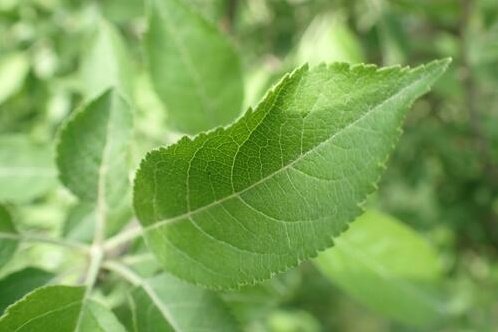

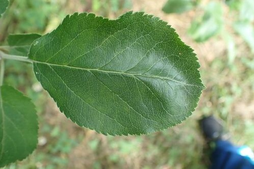

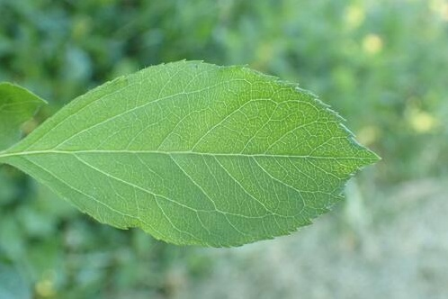

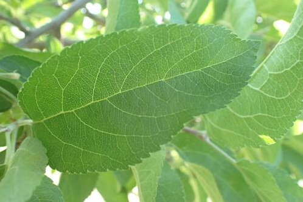

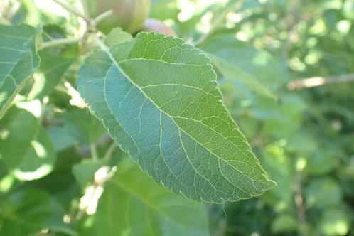

```
Showing 5 samples for class C1
```

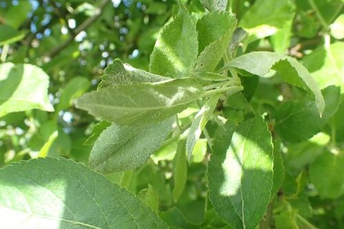

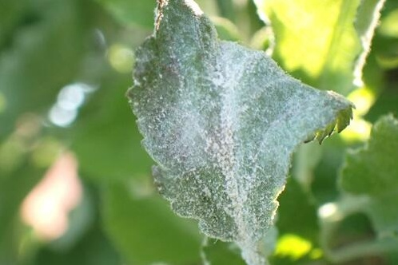

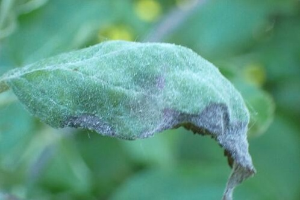

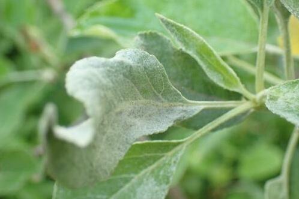

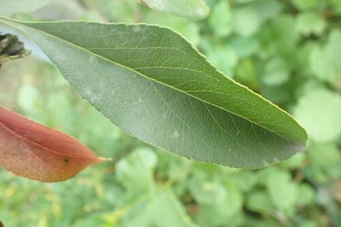

```
Showing 5 samples for class C2
```

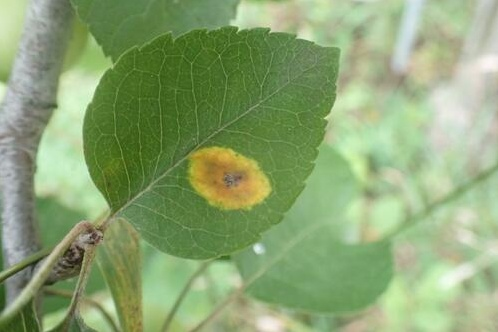

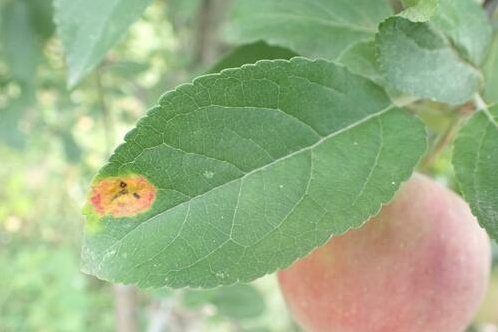

[18 more figures not shown]

```python
# Train/test data paths
TRAIN_DATA_PATH = os.path.join('data', 'train')
TEST_DATA_PATH = os.path.join('data', 'test')

# Max image sample number
MAX_IMG_SAMPLE = 5

# Store train data info for later use
test_data_info = {
    'filename': [],
    'class': [],
    'dynamic-range': [],
    'size': []
}

# Calculate image dynamic range and size
def get_image_info(image_path):
    img = PILImage.open(image_path)
    max_pixel, min_pixel = np.max(img), np.min(img)
    max_pixel_value, min_pixel_value = 0, 100000

    max_pixel_value = max_pixel if max_pixel > max_pixel_value else max_pixel_value
    min_pixel_value = min_pixel if min_pixel < min_pixel_value else min_pixel_value

    dynamic_range = ((max_pixel_value - min_pixel_value) * 100) / 255

    return dynamic_range, f'{img.width}x{img.height}'

# Iterate over train data and get the required image info
for class_folder in os.listdir(TRAIN_DATA_PATH):
    class_path = os.path.join(TRAIN_DATA_PATH, class_folder)
    count = 0
    print(f'\nShowing {MAX_IMG_SAMPLE} samples for class {class_folder}')
    for img in os.listdir(class_path):
        image_path = os.path.join(class_path, img)
        dynamic_range, size = get_image_info(image_path)

        for col, data in zip(list(test_data_info.keys()), (image_path, class_folder, dynamic_range, size)):
            test_data_info.get(col).append(data)

        if count < MAX_IMG_SAMPLE:
            display(Image(filename=image_path))
            count += 1
```

Existen 6 clases diferentes. Una para las hojas sanas y otras 5 para los diferentes tipos de enfermedades que se quieren detectar.

**Análisis de los datos**

```python
_, _, files = next(os.walk(TEST_DATA_PATH))
test_data_count = len(files)
```

```python
df = pd.DataFrame.from_dict(test_data_info)
train_data_count = df.filename.count()
total_data_count = test_data_count + train_data_count

def get_size_in_MB(source):

    # Get every file size from source
    sum_total = (lambda path: sum(f.stat().st_size for f in pathlib.Path(path).glob('**/*') if f.is_file()))

    if type(source) != list:
        return sum_total(source) / (1024 ** 2)

    total = 0
    for path in source:
        total += sum_total(path)

    return total / (1024 ** 2)


print(f'Image data count: {total_data_count}')
print(f' * Total: {total_data_count}')
print(f' * Train: {train_data_count}\t{(test_data_count * 100) / total_data_count}%')
print(f' * Test: {test_data_count}\t{(train_data_count * 100) / total_data_count}%')
print(f" * Total data in MB\t{get_size_in_MB(source=['data/test', 'data/train'])}MB")
```

```
Image data count: 17277
 * Total: 17277
 * Train: 9750	43.566591422121896%
 * Test: 7527	56.433408577878104%
 * Total data in MB	969.9416446685791MB
```

Para cada imagen debe mostrarse el nombre del fichero, la clase, su rango dinámico y sus dimensiones.

```python
df.head(16)
```

|  | filename | class | dynamic-range | size |
| --- | --- | --- | --- | --- |
| 0 | data/train/C0/G8NErW5a2D.jpg | C0 | 100.000000 | 498x332 |
| 1 | data/train/C0/VM7OH1vQk0.jpg | C0 | 100.000000 | 498x332 |
| 2 | data/train/C0/2En1A54wan.jpg | C0 | 92.941176 | 498x332 |
| 3 | data/train/C0/DZ9xzGXUc2.jpg | C0 | 100.000000 | 498x332 |
| 4 | data/train/C0/KsHoYiA1PQ.jpg | C0 | 100.000000 | 498x332 |
| 5 | data/train/C0/tzwfbBAfAa.jpg | C0 | 100.000000 | 498x332 |
| 6 | data/train/C0/XkNOsdlMd7.jpg | C0 | 100.000000 | 498x332 |
| 7 | data/train/C0/uN3oSuj4Rm.jpg | C0 | 100.000000 | 498x373 |
| 8 | data/train/C0/3quETuWzMT.jpg | C0 | 100.000000 | 498x332 |
| 9 | data/train/C0/2l5XkxGsuC.jpg | C0 | 100.000000 | 498x332 |
| 10 | data/train/C0/nVhjjsrJ6g.jpg | C0 | 92.941176 | 498x332 |
| 11 | data/train/C0/53HvvZcJNv.jpg | C0 | 100.000000 | 498x373 |
| 12 | data/train/C0/vXUgg5e9vL.jpg | C0 | 97.254902 | 498x332 |
| 13 | data/train/C0/XAA9vpCIXE.jpg | C0 | 100.000000 | 498x332 |
| 14 | data/train/C0/DtzwRLw1nr.jpg | C0 | 100.000000 | 498x373 |
| 15 | data/train/C0/CLyvajdAao.jpg | C0 | 96.470588 | 498x332 |

Vamos a agrupar los datos de diferentes formas para conocer el estado de las imágenes del conjunto de entrenamiento.

```
Total files per class/percent
Label	Count	Percent
---------------------
C0	4000	41.02564102564103%
C1	1000	10.256410256410257%
C2	1200	12.307692307692308%
C3	1100	11.282051282051283%
C4	1300	13.333333333333334%
C5	1150	11.794871794871796%
```

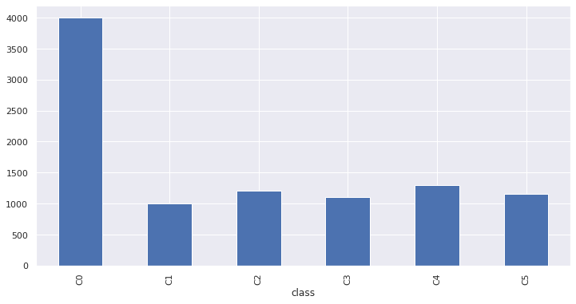

```python
total_values = df[['filename', 'class']].groupby(['class'], sort=True).count().sum()[0]

print('\nTotal files per class/percent')
print('Label\tCount\tPercent')
print('---------------------')
for classname, row in df[['filename', 'class']].groupby(['class'], sort=True).count().iterrows():
    file_count = row['filename']
    print(f'{classname}\t{file_count}\t{(file_count * 100) / total_values}%')


df[['filename', 'class']].groupby(['class'], sort=True).count().plot(kind='bar', figsize=(12, 6), legend=False)
plt.show()
```

```python
print('Image size per class')
df[['class', 'size']].groupby(['size']).count()
```

```
Image size per class
```

| size | class |
| --- | --- |
| 498x279 | 1 |
| 498x331 | 734 |
| 498x332 | 8426 |
| 498x373 | 583 |
| 498x498 | 3 |
| 498x665 | 3 |

```python
df['range'] = df.apply(lambda row: 0 if row.loc['dynamic-range'] < 50 else 1 if 50 <= row.loc['dynamic-range'] < 90 else 2, axis=1)

print(f'Dynamic-range values\nmax: {df.range.max()}\nmin: {df.range.min()}\nmedian: {df.range.median()}')

print('Legend (dynamic-range = dr)\n0: dr < 50\n1: 50 <= dr < 90\n2: dr > 90')
df[['class', 'range']].groupby(['range']).count()
```

```
Dynamic-range values
max: 2
min: 1
median: 2.0
Legend (dynamic-range = dr)
0: dr < 50
1: 50 <= dr < 90
2: dr > 90
```

| range | class |
| --- | --- |
| 1 | 397 |
| 2 | 9353 |

**Conclusiones del análisis**

De los datos de entrenamiento hemos podido comprobar

- Tiene 6 clases diferentes: C0-5.
- Una de ellas es positiva (no hay enfermedad) y el resto es negativa.
- La cantidad de datos para la clase C0 es **cuatro veces mayor** que las del resto C1-5
- Si sumamos la cantidad de imágenes con criterio enfermedad/sano tenemos **5750 / 4000**
- El rango dinámico en general es bastante alto.
- Casi todas las imágenes tienen resolución 498x[331,332,373]
- Las imágenes están hechas desde todos los ángulos y perspectivas

Dependiendo de cómo consideremos en problema podemos tratarlo como un problema de clasificación multiclase, es decir, diferenciar entre todas las clases o binaria (positiva - negativa). De la primera forma tendríamos que nivelar los datos de todas las clases antes de dividir el conjunto, por lo que se podría realizar *data augmentation* para las clases C1-5 hasta los 4000 y así balancear todas las clases. En caso de optar por la segunda opción se podrían mezclar todas las clases en dos: positiva y negativa y en princiìo no parece que sea necesario aumentar artificialmente ninguna clase. El tamaño de las imágenes no es un dato relevante ya que en cualquier caso habrá que hacer *resize* de los datos de entrada para que se adapten a los parámetros del modelo.

### Ejercicio 2

Definición de la estrategia de validación. (División del conjunto de entrenamiento en entrenamiento propiamente dicho y conjunto de validación).

Para elegir la mejor combinación de datos de entrenamiento/validación del conjunto de datos de entrenamiento vamos a realizar un proceso de *cross validation*. En concreto sería interesante crear un método que cargue las imágenes con generadores desde el directorio del conjunto de entrenamiento.

```python
def gen_cv_folds(dataframe, path_col='filename', class_col='class', n_splits=5, seed=1):
    # Split the data into (X,y) format
    cv_data = dataframe[[path_col, class_col]]
    cv_data[path_col] = cv_data[path_col].apply(lambda d: os.path.abspath(d))


    X = cv_data[[path_col]]
    y = cv_data[[class_col]]

    # Create (train, validation) image generator
    img_generator = ImageDataGenerator(rescale=1.0/255.0)


    # Split the data in K folds
    skf = StratifiedKFold(n_splits=n_splits)
    for train_index, val_index in skf.split(X, y):
        train_data  = cv_data.iloc[train_index]
        val_data = cv_data.iloc[val_index]

        train_data_generator = img_generator\
            .flow_from_dataframe(train_data,
                                 class_mode='categorical',
                                 x_col = path_col,
                                 y_col=class_col,
                                 seed=seed,
                                 shuffle=True)

        val_data_generator = img_generator\
            .flow_from_dataframe(val_data,
                                 class_mode='categorical',
                                 x_col = path_col,
                                 y_col=class_col,
                                 seed=seed,
                                 shuffle=True)

        yield train_data_generator, val_data_generator

def get_weight_classes(data_generator):
    return dict(enumerate(class_weight.compute_class_weight(class_weight='balanced',
                                                            classes=np.unique(data_generator.classes),
                                                            y=data_generator.classes)))
```

Con esté metodo podremos elegir la mejor combinación de datos de entrenamiento realizando *cross validation* y además nivelaremos el peso de los datos de las clases en el entrenamiento con el método `get_weight_classes`

```python
# Generate data for first cross validation split and get class weights
train_gen, val_gen = next(gen_cv_folds(df))
train_weights, val_weights = get_weight_classes(train_gen), get_weight_classes(val_gen)

for dataset, weight in zip(('train', 'test'), (train_weights, val_weights)):
    print(f'Class weights for {dataset}\n{weight}')
```

```
Found 7800 validated image filenames belonging to 6 classes.
Found 1950 validated image filenames belonging to 6 classes.
Class weights for train
{0: 0.40625, 1: 1.625, 2: 1.3541666666666667, 3: 1.4772727272727273, 4: 1.25, 5: 1.4130434782608696}
Class weights for test
{0: 0.40625, 1: 1.625, 2: 1.3541666666666667, 3: 1.4772727272727273, 4: 1.25, 5: 1.4130434782608696}
```

Los pesos que ha asignado a cada clase son razonables dada la distribución que tienen en donde la clase tiene muchos más datos que las demás.

### Ejercicio 3

- Definición de la estrategia de aumento de datos sobre el conjunto de entrenamiento.
- Elegir el tipo de modelo y tamaño de imagen de entrada que se utilizará para la predicción.
- Elegir el tipo de estrategia de entrenamiento que se seguirá (entrenamiento desde cero o fine-tuning de un modelo pre-entrenado). Se recomienda fine-tuning.
- Mostrar las gráficas de entrenamiento donde se pueda ver claramente la evolución de la función de pérdida y de la función de evaluación (F1) tanto para el conjunto de entrenamiento como para el de validación.
- Elegir el modelo con mejor rendimiento (aquel que tiene la máxima F1 sobre el conjunto de validación).

**Balanceo de los datos**

En el apartado anterior hemos escrito una función que dado un generador de datos calculará los pesos que deberán utilizarse en el entrenamiento del modelo

**Modelos seleccionados**

En la documentación de `Keras` tenemos una lista de todos los modelos que ofrece su API. Vamos a probar algunos de [los siguientes modelos](https://www.pyimagesearch.com/2017/03/20/imagenet-vggnet-resnet-inception-xception-keras/) los cuales utilizan diferentes arquitecturas de red.

- Xception
- ResNet50
- InceptionV3

[figure not shown]

**ResNet** tiene un tamaño de entrada de **224×224** mientras que **InceptionV3** y **Xception** necesitan un tamaño de 299×299 píxeles. Todos los modelos utilizan 3 canales.

```python
# Create tuple dict with model/input size/preprocessing function values
# We can iterate this dictionary and parse every model with the input size
# and the preprocessing function params

MODELS = {
    'xception': (Xception, (299, 299, 3), preprocess_input),
    'resnet': (ResNet50, (224, 224, 3), imagenet_utils.preprocess_input),
    'inceptionv3': (InceptionV3, (299, 299, 3), preprocess_input)
}
```

**Normalización de las imágenes**

- Tamaño fijo para la capa *input* y añadir una capa de *resize* a la arquitectura de la red.
- Normalizar todas las imágenes al tamaño que requiere el modelo como paso de preprocesamiento. De esta forma arquitectura final tendrá menos capas.

Recorremos todos los datos de entrenamiento/test y vamos a normalizar y a guardar todas las imágenes. Para terminar mostraremos un resumen con los datos que se han guardado con sus clases.

```python
NORM_ROOT = os.path.join('data', 'norm')
NORM_TRAIN = os.path.join(NORM_ROOT, 'train')
MAX_CLASSES = 6

# Get normalized data info
norm_data_info = {
    'filename': [],
    'class': [],
    'model': []
}

# Generate path from model normalized data
def norm_path_gen(root='data/norm/train', class_prefix=None, start=0, end=1):
    for i in range(start, end):
        yield os.path.join(root, f"{class_prefix if class_prefix is not None else ''}{i}")

# Create normalized data strucyture
def create_norm_data_path(model_name):
        root_path = os.path.join(NORM_ROOT, model_name)
        train_path = os.path.join(root_path, 'train')
        test_path = os.path.join(root_path, 'test')

        class_paths = list(norm_path_gen(root=train_path, class_prefix='C', end=MAX_CLASSES))

        for path in [root_path, train_path, test_path] + class_paths:
            pathlib.Path(path).mkdir(parents=True, exist_ok=True)

# Resize image method
def resize_image(path, model_name, width, height):
    normalized_path = path.replace('data', os.path.join('data', 'norm', model_name))

     # if already generated skip resize and save time
    if not os.path.isfile(normalized_path):
        img = PILImage.open(path)
        img = img.resize((width, height), PILImage.ANTIALIAS)
        img.save(normalized_path)

    return normalized_path


# Iterate over models, create data structure and normalize data
for model_name, (_, (width, height, _), _) in MODELS.items():
    print(f'Normalizing data for {model_name}...')
    create_norm_data_path(model_name=model_name)

    # For every class create the resized image in the model normalized data folder
    for dataset in [TEST_DATA_PATH, TRAIN_DATA_PATH]:
        for folder in os.listdir(dataset):
            data_root_path = os.path.join(dataset, folder)

            # Create test or train folders to store the normalized data
            if os.path.isfile(data_root_path):
                resize_image(path=data_root_path, model_name=model_name, width=width, height=height)
            else:
                for img in os.listdir(data_root_path):
                    image_path = os.path.join(data_root_path, img)
                    newpath = resize_image(path=image_path, model_name=model_name, width=width, height=height)
                    for col, data in zip(list(norm_data_info.keys()), (newpath, folder, model_name)):
                        norm_data_info.get(col).append(data)
    print(f'Done')
```

```
Normalizing data for xception...
Done
Normalizing data for resnet...
Done
Normalizing data for inceptionv3...
Done
```

Esta tabla muestra los resultados de la normalización de los datos para todos los modelos y clases. Utilizaremos este `dataframe` para localizar los datos de entrenamiento junto con sus clases con los generadores de datos definidos en el apartado anterior.

```python
df_norm = pd.DataFrame.from_dict(norm_data_info)
df_norm.head(16)
```

|  | filename | class | model |
| --- | --- | --- | --- |
| 0 | data/norm/xception/train/C0/G8NErW5a2D.jpg | C0 | xception |
| 1 | data/norm/xception/train/C0/VM7OH1vQk0.jpg | C0 | xception |
| 2 | data/norm/xception/train/C0/2En1A54wan.jpg | C0 | xception |
| 3 | data/norm/xception/train/C0/DZ9xzGXUc2.jpg | C0 | xception |
| 4 | data/norm/xception/train/C0/KsHoYiA1PQ.jpg | C0 | xception |
| 5 | data/norm/xception/train/C0/tzwfbBAfAa.jpg | C0 | xception |
| 6 | data/norm/xception/train/C0/XkNOsdlMd7.jpg | C0 | xception |
| 7 | data/norm/xception/train/C0/uN3oSuj4Rm.jpg | C0 | xception |
| 8 | data/norm/xception/train/C0/3quETuWzMT.jpg | C0 | xception |
| 9 | data/norm/xception/train/C0/2l5XkxGsuC.jpg | C0 | xception |
| 10 | data/norm/xception/train/C0/nVhjjsrJ6g.jpg | C0 | xception |
| 11 | data/norm/xception/train/C0/53HvvZcJNv.jpg | C0 | xception |
| 12 | data/norm/xception/train/C0/vXUgg5e9vL.jpg | C0 | xception |
| 13 | data/norm/xception/train/C0/XAA9vpCIXE.jpg | C0 | xception |
| 14 | data/norm/xception/train/C0/DtzwRLw1nr.jpg | C0 | xception |
| 15 | data/norm/xception/train/C0/CLyvajdAao.jpg | C0 | xception |

**Estrategia de entrenamiento**

Vamos a instanciar cada uno de estos modelos pero vamos a utilizar el parámetro `include_top=False` para eliminar las últimas capas y a congelar todas las capas restantes para que no se reentrene desde 0. También utilizaremos los pesos de `imagenet` como pesos iniciales de las capas.

Añadiremos tres capas de salida: una capa densa de **1024** unidades con una función `relu`, una capa *dropout* con un `dropout rate` de **0.5** y una capa densa de salida para las 6 clases con una función de activación `softmax`.

```python
def generate_network(network_name, network_constructor, input_size, preprocess_function):
    # Generate base model and freeze middle layers
    base_model = network_constructor(include_top=False, weights='imagenet')
    for layer in base_model.layers:
        layer.trainable = False

    # Remove channels from input size
    h, w, _ = input_size

    # Generate the network with: input and preprocessing -> base model -> output layers
    return Sequential([
        Input(shape=input_size, name= f'{network_name}-input-{h}x{w}'),
        Resizing(height=224, width=224, name=f'{network_name}-resize-224x224'),
        Lambda(preprocess_function, name=f'{network_name}-preprocessing', input_shape=input_size),
        base_model,
        Flatten(input_shape=(224, 224), name=f'{network_name}-flatten'),
        Dense(units=1024, activation='relu', name=f'{network_name}-dense-1024'),
        Dropout(rate=0.5, name=f'{network_name}-dropout'),
        Dense(units=6, activation='softmax', name=f'{network_name}-output')
    ])
```

También vamos a realizar una prueba con diferentes *learning rates* y *optimizers* para elegir los mejores valores para cada modelo. A parte se va a realizar un estudio sobre el tiempo de entrenamiento de cada modelo para tener en cuenta el coste computacional de cada opción. Utilizamos la métrica `f1-score-macro` como función de evaluación como se ha pedido en el enunciado. Para ello utilizamos `tensorflow_addons`

```python
# Store multiple optimizers and learings rates
LEARNING_RATES = (0.0001, 0.001)
OPTIMIZERS = {
    'Adam': (lambda lr: Adam(learning_rate=lr)),
    'SGD': (lambda lr: SGD(learning_rate=lr))
}

# Instantiate optimizers with multiple lr
def generate_optimizers():
    for optimizer_name, optimizer in OPTIMIZERS.items():
        for lr in LEARNING_RATES:
            yield optimizer_name, optimizer(lr), lr

# Train the model and measure time
def train_model(model, optimizer, train_gen, val_gen, epochs, weights, callbacks):
    model.compile(loss='categorical_crossentropy',
                  metrics=[tfa.metrics.F1Score(num_classes=MAX_CLASSES, average='macro')], # f1 metrics
                  optimizer=optimizer)

    start = time.time()
    metrics = model.fit(train_gen,
                        epochs=epochs,
                        shuffle=True,
                        validation_data=val_gen,
                        use_multiprocessing=True,
                        verbose=1,
                        batch_size=16,  # DO NOT TOUCH
                        class_weight=weights,
                        callbacks=[callbacks,
                                   EarlyStopping(monitor='val_loss', patience=10)])
    elapsed = time.time() - start
    return metrics.history, elapsed
```

**Selección del modelo**

En esta parte utilizaremos todo el código creado en apartados anteriores para buscar el mejor modelo. Con una partición del *K Folds* entrenaremos un modelo con **10** épocas usando diferentes *optimizers* y *learning rates*. Una vez creado el modelo guardaremos el *checkpoint* y sus resultados en una estructura para analizar los datos y quedarnos con la mejor combinación.

```python
# Store the training config values and results for later use
EPOCHS = 10
SAVED_MODELS_PATH = os.path.join('tmp', '{nn_name}-{opt_name}-{lr}.h5')
MODEL_SELECTION_RESULTS = 'metrics_results.csv'
METRICS = {
    'nn': [],
    'opt': [],
    'lr': [],
    'f1_score': [],
    'val_f1_score': [],
    'loss': [],
    'val_loss': [],
    'elapsed': [],
    'file': []
}

def save_metrics(log, values):
    def _update_metrics(log, col, value):
        if col not in log.keys():
            raise ValueError(f'{col} must be in {log.keys()}')
        if value is None:
            raise ValueError(f'Need a non null value for {col}')

        log.get(col).append(value)

    for col, value in zip(log.keys(), values):
        _update_metrics(log=log, col=col, value=value)

# Skip training if saved
if not os.path.isfile(MODEL_SELECTION_RESULTS):

    # df_norm: normalization paths data for training process
    # get_weight_classes: training balance calculating class data presence in the train dataset
    # models: dictionary with all the nn with name, keras instance, input size and preprocess function
    # gen_cv_folds: generate kfold (default 5 folds) for the training data

    for nn_name, (nn_instance, size, prepro) in MODELS.items():
        print(f' ====== [CREATE][{nn_name}] ====== ')
        # Get normalized data for model and one instance for the NN
        df_nn_data = df_norm[df_norm.model == nn_name]
        clear_session()
        model = generate_network(network_name=nn_name,
                                 network_constructor=nn_instance,
                                 input_size=size,
                                 preprocess_function=prepro)

        # Get one train/val data generators for NN
        # train with different lr and optimizers and fit multiple times over the same model instance
        # https://stackoverflow.com/questions/49841324/what-does-calling-fit-multiple-times-on-the-same-model-do
        train_data, val_data = next(gen_cv_folds(df_nn_data))
        for opt_name, opt, lr in generate_optimizers():

            print(f' ====== [TRAINING][{nn_name}][epochs:{EPOCHS}][opt:{opt_name}][lr:{lr}] ====== ')
            model_file = SAVED_MODELS_PATH.format(nn_name=nn_name,
                                                  opt_name=opt_name.lower(),
                                                  lr=lr)

            cp_checkpoint = ModelCheckpoint(model_file,
                                            monitor='val_f1_score',
                                            verbose=0,
                                            save_weights_only=True)

            history, elapsed = train_model(model=model,
                                           optimizer=opt,
                                           train_gen=train_data,
                                           val_gen=val_data,
                                           epochs=EPOCHS,
                                           weights=train_weights,
                                           callbacks=cp_checkpoint)

            for f1, loss, val_f1, val_loss in zip(history['f1_score'], history['loss'], history['val_f1_score'], history['val_loss']):
                save_metrics(log=METRICS,
                             values=(nn_name, opt_name, lr, f1, val_f1, loss, val_loss, elapsed, model_file))

            # Dump metrics to CSV in root path
            df_results = pd.DataFrame.from_dict(METRICS)
            df_results.to_csv(MODEL_SELECTION_RESULTS, index=False, header=True)

            print(f' ====== [DONE][{nn_name}][elapsed:{elapsed}s][file:{model_file}] ====== ')
```

```
 ====== [CREATE][xception] ======
WARNING:tensorflow:Please add `keras.layers.InputLayer` instead of `keras.Input` to Sequential model. `keras.Input` is intended to be used by Functional model.
Found 7800 validated image filenames belonging to 6 classes.
Found 1950 validated image filenames belonging to 6 classes.
 ====== [TRAINING][xception][epochs:10][opt:Adam][lr:0.0001] ======
WARNING:tensorflow:From /home/antonio/Documentos/code/deep-learning-uoc/env/lib/python3.9/site-packages/tensorflow/python/ops/array_ops.py:5043: calling gather (from tensorflow.python.ops.array_ops) with validate_indices is deprecated and will be removed in a future version.
Instructions for updating:
The `validate_indices` argument has no effect. Indices are always validated on CPU and never validated on GPU.
Epoch 1/10
244/244 [==============================] - 81s 260ms/step - loss: 1.8103 - f1_score: 0.1645 - val_loss: 1.7741 - val_f1_score: 0.1805
Epoch 2/10
244/244 [==============================] - 62s 251ms/step - loss: 1.7664 - f1_score: 0.1837 - val_loss: 1.7137 - val_f1_score: 0.2015
Epoch 3/10
244/244 [==============================] - 61s 251ms/step - loss: 1.7473 - f1_score: 0.2083 - val_loss: 1.7040 - val_f1_score: 0.2162
Epoch 4/10
244/244 [==============================] - 61s 251ms/step - loss: 1.7303 - f1_score: 0.2203 - val_loss: 1.6680 - val_f1_score: 0.2279
Epoch 5/10
244/244 [==============================] - 62s 251ms/step - loss: 1.6739 - f1_score: 0.2310 - val_loss: 1.6786 - val_f1_score: 0.2363
Epoch 6/10
244/244 [==============================] - 61s 251ms/step - loss: 1.6510 - f1_score: 0.2384 - val_loss: 1.6868 - val_f1_score: 0.2430s
Epoch 7/10
244/244 [==============================] - 62s 251ms/step - loss: 1.6627 - f1_score: 0.2445 - val_loss: 1.5982 - val_f1_score: 0.2475
Epoch 8/10
244/244 [==============================] - 62s 253ms/step - loss: 1.6672 - f1_score: 0.2498 - val_loss: 1.5732 - val_f1_score: 0.2536
Epoch 9/10
244/244 [==============================] - 62s 251ms/step - loss: 1.6565 - f1_score: 0.2559 - val_loss: 1.6068 - val_f1_score: 0.2591
Epoch 10/10
244/244 [==============================] - 62s 254ms/step - loss: 1.6112 - f1_score: 0.2606 - val_loss: 1.6166 - val_f1_score: 0.2627
 ====== [DONE][xception][elapsed:676.4210789203644s][file:tmp/xception-adam-0.0001.h5] ======
 ====== [TRAINING][xception][epochs:10][opt:Adam][lr:0.001] ======
Epoch 1/10
244/244 [==============================] - 66s 257ms/step - loss: 1.7842 - f1_score: 0.1775 - val_loss: 1.7908 - val_f1_score: 0.1246
Epoch 2/10
244/244 [==============================] - 62s 253ms/step - loss: 1.7990 - f1_score: 0.1167 - val_loss: 1.7914 - val_f1_score: 0.1028
Epoch 3/10
244/244 [==============================] - 62s 252ms/step - loss: 1.7871 - f1_score: 0.1030 - val_loss: 1.7919 - val_f1_score: 0.1038
Epoch 4/10
244/244 [==============================] - 62s 253ms/step - loss: 1.8064 - f1_score: 0.1015 - val_loss: 1.7911 - val_f1_score: 0.0961
Epoch 5/10
244/244 [==============================] - 62s 252ms/step - loss: 1.7771 - f1_score: 0.1025 - val_loss: 1.7908 - val_f1_score: 0.1135
Epoch 6/10
244/244 [==============================] - 62s 252ms/step - loss: 1.8082 - f1_score: 0.1126 - val_loss: 1.7914 - val_f1_score: 0.1157
Epoch 7/10
244/244 [==============================] - 62s 252ms/step - loss: 1.7850 - f1_score: 0.1184 - val_loss: 1.7926 - val_f1_score: 0.1237
Epoch 8/10
244/244 [==============================] - 62s 253ms/step - loss: 1.7983 - f1_score: 0.1249 - val_loss: 1.7923 - val_f1_score: 0.1275
Epoch 9/10
244/244 [==============================] - 62s 253ms/step - loss: 1.7828 - f1_score: 0.1302 - val_loss: 1.7926 - val_f1_score: 0.1351
Epoch 10/10
244/244 [==============================] - 62s 252ms/step - loss: 1.7934 - f1_score: 0.1362 - val_loss: 1.7920 - val_f1_score: 0.1373
 ====== [DONE][xception][elapsed:661.9114811420441s][file:tmp/xception-adam-0.001.h5] ======
 ====== [TRAINING][xception][epochs:10][opt:SGD][lr:0.0001] ======
Epoch 1/10
244/244 [==============================] - 62s 241ms/step - loss: 1.8117 - f1_score: 0.0339 - val_loss: 1.7920 - val_f1_score: 0.0353
Epoch 2/10
244/244 [==============================] - 58s 238ms/step - loss: 1.7881 - f1_score: 0.0351 - val_loss: 1.7920 - val_f1_score: 0.0351
Epoch 3/10
244/244 [==============================] - 58s 238ms/step - loss: 1.8013 - f1_score: 0.0352 - val_loss: 1.7920 - val_f1_score: 0.0352
Epoch 4/10
244/244 [==============================] - 58s 238ms/step - loss: 1.7876 - f1_score: 0.0352 - val_loss: 1.7920 - val_f1_score: 0.0352
Epoch 5/10
244/244 [==============================] - 58s 237ms/step - loss: 1.7721 - f1_score: 0.0351 - val_loss: 1.7920 - val_f1_score: 0.0352
Epoch 6/10
244/244 [==============================] - 58s 237ms/step - loss: 1.7953 - f1_score: 0.0352 - val_loss: 1.7920 - val_f1_score: 0.0352
Epoch 7/10
244/244 [==============================] - 58s 238ms/step - loss: 1.7885 - f1_score: 0.0352 - val_loss: 1.7920 - val_f1_score: 0.0352
Epoch 8/10
244/244 [==============================] - 58s 237ms/step - loss: 1.7935 - f1_score: 0.0351 - val_loss: 1.7920 - val_f1_score: 0.0352
Epoch 9/10
244/244 [==============================] - 58s 236ms/step - loss: 1.7951 - f1_score: 0.0352 - val_loss: 1.7920 - val_f1_score: 0.0352
Epoch 10/10
244/244 [==============================] - 57s 235ms/step - loss: 1.7904 - f1_score: 0.0352 - val_loss: 1.7920 - val_f1_score: 0.0352
 ====== [DONE][xception][elapsed:627.3157384395599s][file:tmp/xception-sgd-0.0001.h5] ======
 ====== [TRAINING][xception][epochs:10][opt:SGD][lr:0.001] ======
Epoch 1/10
244/244 [==============================] - 61s 238ms/step - loss: 1.7822 - f1_score: 0.0521 - val_loss: 1.7920 - val_f1_score: 0.0594
Epoch 2/10
244/244 [==============================] - 57s 235ms/step - loss: 1.7912 - f1_score: 0.0603 - val_loss: 1.7920 - val_f1_score: 0.0683
Epoch 3/10
244/244 [==============================] - 57s 235ms/step - loss: 1.8030 - f1_score: 0.0672 - val_loss: 1.7919 - val_f1_score: 0.0650
Epoch 4/10
244/244 [==============================] - 58s 235ms/step - loss: 1.7926 - f1_score: 0.0641 - val_loss: 1.7919 - val_f1_score: 0.0627
Epoch 5/10
244/244 [==============================] - 58s 235ms/step - loss: 1.7974 - f1_score: 0.0626 - val_loss: 1.7919 - val_f1_score: 0.0674
Epoch 6/10
244/244 [==============================] - 57s 234ms/step - loss: 1.7841 - f1_score: 0.0667 - val_loss: 1.7919 - val_f1_score: 0.0650
Epoch 7/10
244/244 [==============================] - 58s 235ms/step - loss: 1.7826 - f1_score: 0.0644 - val_loss: 1.7919 - val_f1_score: 0.0629
Epoch 8/10
244/244 [==============================] - 57s 234ms/step - loss: 1.8026 - f1_score: 0.0631 - val_loss: 1.7919 - val_f1_score: 0.0644
Epoch 9/10
244/244 [==============================] - 57s 234ms/step - loss: 1.7937 - f1_score: 0.0655 - val_loss: 1.7919 - val_f1_score: 0.0673
Epoch 10/10
244/244 [==============================] - 58s 235ms/step - loss: 1.7862 - f1_score: 0.0671 - val_loss: 1.7919 - val_f1_score: 0.0672
 ====== [DONE][xception][elapsed:621.732428073883s][file:tmp/xception-sgd-0.001.h5] ======
 ====== [CREATE][resnet] ======
WARNING:tensorflow:Please add `keras.layers.InputLayer` instead of `keras.Input` to Sequential model. `keras.Input` is intended to be used by Functional model.
Found 7800 validated image filenames belonging to 6 classes.
Found 1950 validated image filenames belonging to 6 classes.
 ====== [TRAINING][resnet][epochs:10][opt:Adam][lr:0.0001] ======
Epoch 1/10
244/244 [==============================] - 54s 207ms/step - loss: 2.4818 - f1_score: 0.1507 - val_loss: 1.7917 - val_f1_score: 0.1428
Epoch 2/10
244/244 [==============================] - 49s 200ms/step - loss: 1.8001 - f1_score: 0.1312 - val_loss: 1.8254 - val_f1_score: 0.1227
Epoch 3/10
244/244 [==============================] - 49s 198ms/step - loss: 1.7929 - f1_score: 0.1217 - val_loss: 1.7856 - val_f1_score: 0.1179
Epoch 4/10
244/244 [==============================] - 49s 199ms/step - loss: 1.8063 - f1_score: 0.1169 - val_loss: 1.7674 - val_f1_score: 0.1141
Epoch 5/10
244/244 [==============================] - 49s 198ms/step - loss: 1.7815 - f1_score: 0.1133 - val_loss: 1.7805 - val_f1_score: 0.1126
Epoch 6/10
244/244 [==============================] - 49s 199ms/step - loss: 1.7621 - f1_score: 0.1120 - val_loss: 1.7742 - val_f1_score: 0.1101
Epoch 7/10
244/244 [==============================] - 49s 198ms/step - loss: 1.7819 - f1_score: 0.1096 - val_loss: 1.7689 - val_f1_score: 0.1082
Epoch 8/10
244/244 [==============================] - 49s 198ms/step - loss: 1.7936 - f1_score: 0.1077 - val_loss: 1.7742 - val_f1_score: 0.1065
Epoch 9/10
244/244 [==============================] - 49s 199ms/step - loss: 1.7877 - f1_score: 0.1062 - val_loss: 1.7837 - val_f1_score: 0.1048
Epoch 10/10
244/244 [==============================] - 49s 198ms/step - loss: 1.7927 - f1_score: 0.1041 - val_loss: 1.7655 - val_f1_score: 0.1032
 ====== [DONE][resnet][elapsed:535.1265370845795s][file:tmp/resnet-adam-0.0001.h5] ======
 ====== [TRAINING][resnet][epochs:10][opt:Adam][lr:0.001] ======
Epoch 1/10
244/244 [==============================] - 54s 205ms/step - loss: 1.8015 - f1_score: 0.0676 - val_loss: 1.7940 - val_f1_score: 0.0693
Epoch 2/10
244/244 [==============================] - 49s 200ms/step - loss: 1.8021 - f1_score: 0.0809 - val_loss: 1.7919 - val_f1_score: 0.0992
Epoch 3/10
244/244 [==============================] - 49s 200ms/step - loss: 1.8150 - f1_score: 0.0979 - val_loss: 1.7915 - val_f1_score: 0.0969
Epoch 4/10
244/244 [==============================] - 49s 200ms/step - loss: 1.7927 - f1_score: 0.1018 - val_loss: 1.7902 - val_f1_score: 0.1202
Epoch 5/10
244/244 [==============================] - 49s 200ms/step - loss: 1.7710 - f1_score: 0.1274 - val_loss: 1.7921 - val_f1_score: 0.1264
Epoch 6/10
244/244 [==============================] - 49s 199ms/step - loss: 1.7959 - f1_score: 0.1288 - val_loss: 1.7920 - val_f1_score: 0.1345
Epoch 7/10
244/244 [==============================] - 49s 200ms/step - loss: 1.7989 - f1_score: 0.1360 - val_loss: 1.7918 - val_f1_score: 0.1364
Epoch 8/10
244/244 [==============================] - 50s 202ms/step - loss: 1.7790 - f1_score: 0.1370 - val_loss: 1.7921 - val_f1_score: 0.1361
Epoch 9/10
244/244 [==============================] - 49s 201ms/step - loss: 1.7861 - f1_score: 0.1359 - val_loss: 1.7924 - val_f1_score: 0.1379
Epoch 10/10
244/244 [==============================] - 50s 205ms/step - loss: 1.7968 - f1_score: 0.1372 - val_loss: 1.7927 - val_f1_score: 0.1356
 ====== [DONE][resnet][elapsed:539.7056746482849s][file:tmp/resnet-adam-0.001.h5] ======
 ====== [TRAINING][resnet][epochs:10][opt:SGD][lr:0.0001] ======
Epoch 1/10
244/244 [==============================] - 51s 196ms/step - loss: 1.7868 - f1_score: 0.0417 - val_loss: 1.7927 - val_f1_score: 0.0603
Epoch 2/10
244/244 [==============================] - 47s 190ms/step - loss: 1.7783 - f1_score: 0.0590 - val_loss: 1.7927 - val_f1_score: 0.0581
Epoch 3/10
244/244 [==============================] - 46s 186ms/step - loss: 1.7832 - f1_score: 0.0590 - val_loss: 1.7927 - val_f1_score: 0.0594
Epoch 4/10
244/244 [==============================] - 46s 188ms/step - loss: 1.7653 - f1_score: 0.0594 - val_loss: 1.7927 - val_f1_score: 0.0590
Epoch 5/10
244/244 [==============================] - 46s 187ms/step - loss: 1.7848 - f1_score: 0.0585 - val_loss: 1.7927 - val_f1_score: 0.0579
Epoch 6/10
244/244 [==============================] - 46s 188ms/step - loss: 1.7774 - f1_score: 0.0579 - val_loss: 1.7927 - val_f1_score: 0.0595
Epoch 7/10
244/244 [==============================] - 46s 186ms/step - loss: 1.7918 - f1_score: 0.0595 - val_loss: 1.7927 - val_f1_score: 0.0597
Epoch 8/10
244/244 [==============================] - 46s 186ms/step - loss: 1.8195 - f1_score: 0.0595 - val_loss: 1.7927 - val_f1_score: 0.0595
Epoch 9/10
244/244 [==============================] - 46s 188ms/step - loss: 1.7993 - f1_score: 0.0595 - val_loss: 1.7926 - val_f1_score: 0.0589
```

```
Epoch 10/10
244/244 [==============================] - 46s 187ms/step - loss: 1.7791 - f1_score: 0.0590 - val_loss: 1.7926 - val_f1_score: 0.0591
 ====== [DONE][resnet][elapsed:508.00272250175476s][file:tmp/resnet-sgd-0.0001.h5] ======
 ====== [TRAINING][resnet][epochs:10][opt:SGD][lr:0.001] ======
Epoch 1/10
244/244 [==============================] - 50s 192ms/step - loss: 1.7910 - f1_score: 0.0498 - val_loss: 1.7926 - val_f1_score: 0.0596
Epoch 2/10
244/244 [==============================] - 46s 187ms/step - loss: 1.8008 - f1_score: 0.0623 - val_loss: 1.7926 - val_f1_score: 0.0618
Epoch 3/10
244/244 [==============================] - 46s 186ms/step - loss: 1.8007 - f1_score: 0.0626 - val_loss: 1.7925 - val_f1_score: 0.0622
Epoch 4/10
244/244 [==============================] - 46s 187ms/step - loss: 1.7970 - f1_score: 0.0623 - val_loss: 1.7925 - val_f1_score: 0.0617
Epoch 5/10
244/244 [==============================] - 46s 186ms/step - loss: 1.7914 - f1_score: 0.0619 - val_loss: 1.7925 - val_f1_score: 0.0617
Epoch 6/10
244/244 [==============================] - 45s 185ms/step - loss: 1.7822 - f1_score: 0.0619 - val_loss: 1.7924 - val_f1_score: 0.0621
Epoch 7/10
244/244 [==============================] - 46s 185ms/step - loss: 1.8060 - f1_score: 0.0621 - val_loss: 1.7924 - val_f1_score: 0.0621
Epoch 8/10
244/244 [==============================] - 45s 184ms/step - loss: 1.8054 - f1_score: 0.0622 - val_loss: 1.7924 - val_f1_score: 0.0621
Epoch 9/10
244/244 [==============================] - 45s 185ms/step - loss: 1.8089 - f1_score: 0.0621 - val_loss: 1.7924 - val_f1_score: 0.0618
Epoch 10/10
244/244 [==============================] - 46s 186ms/step - loss: 1.7908 - f1_score: 0.0619 - val_loss: 1.7923 - val_f1_score: 0.0619
 ====== [DONE][resnet][elapsed:502.31406354904175s][file:tmp/resnet-sgd-0.001.h5] ======
 ====== [CREATE][inceptionv3] ======
WARNING:tensorflow:Please add `keras.layers.InputLayer` instead of `keras.Input` to Sequential model. `keras.Input` is intended to be used by Functional model.
Found 7800 validated image filenames belonging to 6 classes.
Found 1950 validated image filenames belonging to 6 classes.
 ====== [TRAINING][inceptionv3][epochs:10][opt:Adam][lr:0.0001] ======
Epoch 1/10
244/244 [==============================] - 44s 156ms/step - loss: 1.9621 - f1_score: 0.1788 - val_loss: 1.5892 - val_f1_score: 0.2413
Epoch 2/10
244/244 [==============================] - 35s 142ms/step - loss: 1.6583 - f1_score: 0.2514 - val_loss: 1.5744 - val_f1_score: 0.2691
Epoch 3/10
244/244 [==============================] - 35s 143ms/step - loss: 1.5948 - f1_score: 0.2748 - val_loss: 1.5193 - val_f1_score: 0.2860
Epoch 4/10
244/244 [==============================] - 35s 142ms/step - loss: 1.5949 - f1_score: 0.2895 - val_loss: 1.5154 - val_f1_score: 0.2990
Epoch 5/10
244/244 [==============================] - 35s 143ms/step - loss: 1.5427 - f1_score: 0.3029 - val_loss: 1.4643 - val_f1_score: 0.3098
Epoch 6/10
244/244 [==============================] - 35s 143ms/step - loss: 1.5463 - f1_score: 0.3122 - val_loss: 1.5836 - val_f1_score: 0.3162
Epoch 7/10
244/244 [==============================] - 35s 144ms/step - loss: 1.4996 - f1_score: 0.3182 - val_loss: 1.4633 - val_f1_score: 0.3236
Epoch 8/10
244/244 [==============================] - 35s 143ms/step - loss: 1.4826 - f1_score: 0.3260 - val_loss: 1.4692 - val_f1_score: 0.3302
Epoch 9/10
244/244 [==============================] - 34s 139ms/step - loss: 1.4868 - f1_score: 0.3321 - val_loss: 1.5034 - val_f1_score: 0.3364
Epoch 10/10
244/244 [==============================] - 35s 143ms/step - loss: 1.4699 - f1_score: 0.3381 - val_loss: 1.4118 - val_f1_score: 0.3415
 ====== [DONE][inceptionv3][elapsed:387.2144567966461s][file:tmp/inceptionv3-adam-0.0001.h5] ======
 ====== [TRAINING][inceptionv3][epochs:10][opt:Adam][lr:0.001] ======
Epoch 1/10
244/244 [==============================] - 41s 149ms/step - loss: 1.8162 - f1_score: 0.1959 - val_loss: 1.7720 - val_f1_score: 0.1761
Epoch 2/10
244/244 [==============================] - 35s 143ms/step - loss: 1.7656 - f1_score: 0.1753 - val_loss: 1.7468 - val_f1_score: 0.1871
Epoch 3/10
244/244 [==============================] - 35s 144ms/step - loss: 1.7785 - f1_score: 0.1857 - val_loss: 1.7431 - val_f1_score: 0.1838
Epoch 4/10
244/244 [==============================] - 35s 143ms/step - loss: 1.7362 - f1_score: 0.1851 - val_loss: 1.7328 - val_f1_score: 0.1880
Epoch 5/10
244/244 [==============================] - 36s 145ms/step - loss: 1.7472 - f1_score: 0.1871 - val_loss: 1.7728 - val_f1_score: 0.1825
Epoch 6/10
244/244 [==============================] - 35s 142ms/step - loss: 1.7623 - f1_score: 0.1817 - val_loss: 1.6211 - val_f1_score: 0.1835
Epoch 7/10
244/244 [==============================] - 35s 144ms/step - loss: 1.7210 - f1_score: 0.1861 - val_loss: 1.6794 - val_f1_score: 0.1879
Epoch 8/10
244/244 [==============================] - 35s 142ms/step - loss: 1.7236 - f1_score: 0.1884 - val_loss: 1.6153 - val_f1_score: 0.1885
Epoch 9/10
244/244 [==============================] - 35s 143ms/step - loss: 1.7040 - f1_score: 0.1904 - val_loss: 1.7516 - val_f1_score: 0.1899
Epoch 10/10
244/244 [==============================] - 35s 143ms/step - loss: 1.7148 - f1_score: 0.1895 - val_loss: 1.6126 - val_f1_score: 0.1912
 ====== [DONE][inceptionv3][elapsed:386.9849805831909s][file:tmp/inceptionv3-adam-0.001.h5] ======
 ====== [TRAINING][inceptionv3][epochs:10][opt:SGD][lr:0.0001] ======
Epoch 1/10
244/244 [==============================] - 39s 144ms/step - loss: 1.7015 - f1_score: 0.1806 - val_loss: 1.6064 - val_f1_score: 0.2139
Epoch 2/10
244/244 [==============================] - 34s 137ms/step - loss: 1.6813 - f1_score: 0.2247 - val_loss: 1.5989 - val_f1_score: 0.2257
Epoch 3/10
244/244 [==============================] - 34s 138ms/step - loss: 1.6771 - f1_score: 0.2295 - val_loss: 1.5987 - val_f1_score: 0.2307
Epoch 4/10
244/244 [==============================] - 34s 137ms/step - loss: 1.6648 - f1_score: 0.2328 - val_loss: 1.5963 - val_f1_score: 0.2314
Epoch 5/10
244/244 [==============================] - 34s 137ms/step - loss: 1.6814 - f1_score: 0.2333 - val_loss: 1.5971 - val_f1_score: 0.2339
Epoch 6/10
244/244 [==============================] - 33s 134ms/step - loss: 1.6861 - f1_score: 0.2352 - val_loss: 1.5972 - val_f1_score: 0.2345
Epoch 7/10
244/244 [==============================] - 33s 134ms/step - loss: 1.6640 - f1_score: 0.2353 - val_loss: 1.5950 - val_f1_score: 0.2342
Epoch 8/10
244/244 [==============================] - 33s 133ms/step - loss: 1.6511 - f1_score: 0.2352 - val_loss: 1.5934 - val_f1_score: 0.2350
Epoch 9/10
244/244 [==============================] - 33s 134ms/step - loss: 1.6681 - f1_score: 0.2356 - val_loss: 1.5899 - val_f1_score: 0.2354
Epoch 10/10
244/244 [==============================] - 33s 133ms/step - loss: 1.6861 - f1_score: 0.2358 - val_loss: 1.5893 - val_f1_score: 0.2353
 ====== [DONE][inceptionv3][elapsed:368.032427072525s][file:tmp/inceptionv3-sgd-0.0001.h5] ======
 ====== [TRAINING][inceptionv3][epochs:10][opt:SGD][lr:0.001] ======
Epoch 1/10
244/244 [==============================] - 38s 140ms/step - loss: 1.6728 - f1_score: 0.2148 - val_loss: 1.5991 - val_f1_score: 0.2283
Epoch 2/10
244/244 [==============================] - 33s 133ms/step - loss: 1.6597 - f1_score: 0.2372 - val_loss: 1.5814 - val_f1_score: 0.2382
Epoch 3/10
244/244 [==============================] - 33s 133ms/step - loss: 1.6434 - f1_score: 0.2405 - val_loss: 1.6057 - val_f1_score: 0.2377
Epoch 4/10
244/244 [==============================] - 33s 133ms/step - loss: 1.6630 - f1_score: 0.2387 - val_loss: 1.6035 - val_f1_score: 0.2377
Epoch 5/10
244/244 [==============================] - 33s 132ms/step - loss: 1.6505 - f1_score: 0.2370 - val_loss: 1.5786 - val_f1_score: 0.2371
Epoch 6/10
244/244 [==============================] - 33s 133ms/step - loss: 1.6694 - f1_score: 0.2380 - val_loss: 1.5780 - val_f1_score: 0.2375
Epoch 7/10
244/244 [==============================] - 33s 133ms/step - loss: 1.6503 - f1_score: 0.2387 - val_loss: 1.5837 - val_f1_score: 0.2386
Epoch 8/10
244/244 [==============================] - 33s 134ms/step - loss: 1.6466 - f1_score: 0.2397 - val_loss: 1.5738 - val_f1_score: 0.2398
Epoch 9/10
244/244 [==============================] - 33s 134ms/step - loss: 1.6685 - f1_score: 0.2403 - val_loss: 1.5623 - val_f1_score: 0.2401
Epoch 10/10
244/244 [==============================] - 33s 134ms/step - loss: 1.6454 - f1_score: 0.2407 - val_loss: 1.6132 - val_f1_score: 0.2403
 ====== [DONE][inceptionv3][elapsed:362.6540334224701s][file:tmp/inceptionv3-sgd-0.001.h5] ======
```

Una vez entrenados los modelos procedemos a mostrar los resultados de la función de validación y pérdida para todos los casos.

| nn | opt | lr | f1_score | val_f1_score |
| --- | --- | --- | --- | --- |
| inceptionv3 | Adam | 0.0001 | 0.339099 | 0.341527 |
|  |  | 0.0010 | 0.190465 | 0.191181 |
|  | SGD | 0.0001 | 0.235245 | 0.235375 |
|  |  | 0.0010 | 0.240374 | 0.240276 |
| resnet | Adam | 0.0001 | 0.152517 | 0.142795 |
|  |  | 0.0010 | 0.136973 | 0.137896 |
|  | SGD | 0.0001 | 0.059679 | 0.060267 |
|  |  | 0.0010 | 0.062567 | 0.062191 |
| xception | Adam | 0.0001 | 0.261174 | 0.262710 |
|  |  | 0.0010 | 0.152703 | 0.137314 |
|  | SGD | 0.0001 | 0.035235 | 0.035278 |
|  |  | 0.0010 | 0.067235 | 0.068295 |

| nn | opt | lr | loss | val_loss |
| --- | --- | --- | --- | --- |
| inceptionv3 | Adam | 0.0001 | 1.805604 | 1.589152 |
|  |  | 0.0010 | 1.775354 | 1.772814 |
|  | SGD | 0.0001 | 1.685761 | 1.606422 |
|  |  | 0.0010 | 1.676865 | 1.613214 |
| resnet | Adam | 0.0001 | 2.005688 | 1.825395 |
|  |  | 0.0010 | 1.792004 | 1.794042 |
|  | SGD | 0.0001 | 1.791765 | 1.792676 |
|  |  | 0.0010 | 1.791779 | 1.792607 |
| xception | Adam | 0.0001 | 1.803399 | 1.774150 |
|  |  | 0.0010 | 1.792057 | 1.792579 |
|  | SGD | 0.0001 | 1.791762 | 1.791981 |
|  |  | 0.0010 | 1.791776 | 1.791967 |

| nn | opt | lr | elapsed |
| --- | --- | --- | --- |
| inceptionv3 | Adam | 0.0001 | 387.214457 |
|  |  | 0.0010 | 386.984981 |
|  | SGD | 0.0001 | 368.032427 |
|  |  | 0.0010 | 362.654033 |
| resnet | Adam | 0.0001 | 535.126537 |
|  |  | 0.0010 | 539.705675 |
|  | SGD | 0.0001 | 508.002723 |
|  |  | 0.0010 | 502.314064 |
| xception | Adam | 0.0001 | 676.421079 |
|  |  | 0.0010 | 661.911481 |
|  | SGD | 0.0001 | 627.315738 |
|  |  | 0.0010 | 621.732428 |

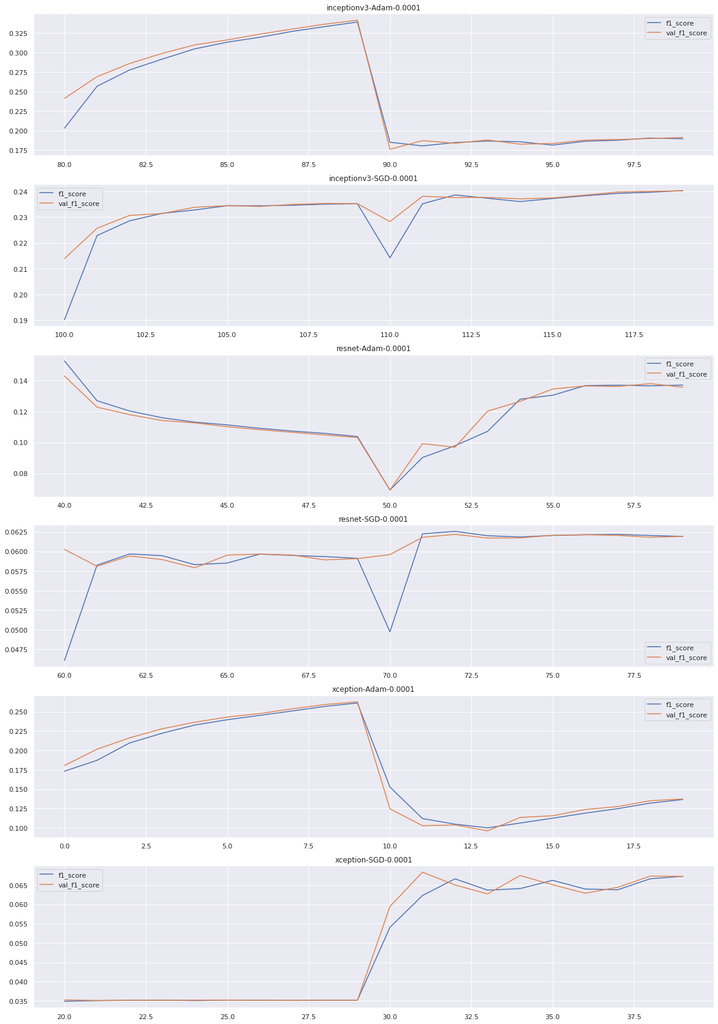

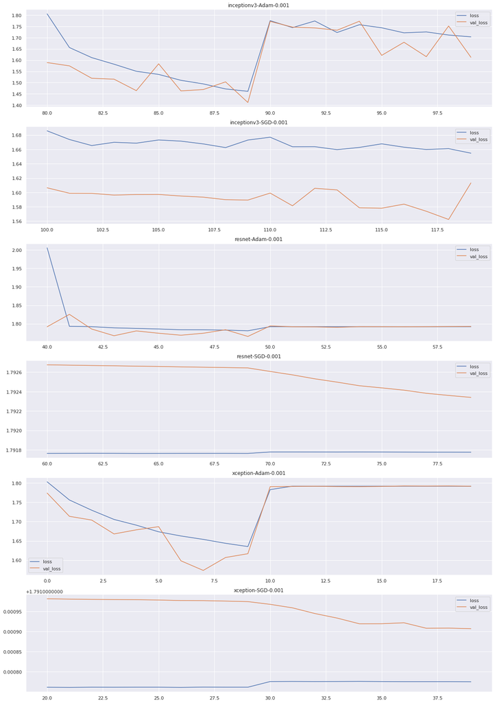

```python
# Select the desired data from results df
base = ['nn', 'opt']
to_remove = ['elapsed', 'lr']
plot_metrics = ['f1_score', 'loss']

# Load results if saved
if os.path.isfile(MODEL_SELECTION_RESULTS):
    df_results = pd.read_csv(MODEL_SELECTION_RESULTS)

for metric, lr in zip(plot_metrics, LEARNING_RATES):
    selected = base + [f'{metric}', f'val_{metric}']
    grouped = df_results.drop(to_remove, axis=1)[selected].groupby(base)
    fig, axs = plt.subplots(nrows=len(grouped.groups.keys()), ncols=1)

    for key, ax in zip(grouped.groups.keys(), axs):
        nn, opt = key
        grouped.get_group(key).plot(title=f'{nn}-{opt}-{lr}', ax=ax, figsize=(20, 30))

# Plot best metrics tables for every model for train/val datasets
for metric in plot_metrics:
    selected = base + [f'{metric}', f'val_{metric}'] + ['lr']
    display(df_results[selected].groupby(base + ['lr']).max())

display(df_results[base + ['elapsed', 'lr']].groupby(base + ['lr']).mean())
```

Como conclusiones a este estudio de diferentes arquitecturas de redes neuronales para este problema de clasificación podemos concluir que el mejor modelo que podemos conseguir es el siguiente:

Inceptionv3 con una función de optimización Adam y una tasa de aprendizaje de 0.0001. Entrenaremos este modelo durante 50 épocas. Además ha sido el modelo con los tiempos de entrenamientos más rápidos por lo que ahorraremos recursos eligiendo esta propuesta.

*Cross validation* con el mejor modelo

```python
CV_MODELS_PATH = os.path.join('tmp', 'cv{cv}-{nn_name}-{opt_name}-{lr}.h5')
BEST_MODEL_EPOCHS = 50
network, size, prepro = MODELS.get('inceptionv3')
lr = 0.0001
nn = 'inceptionv3'
optimizer_name = 'adam'
CV_METRICS_RESULTS = 'best_model_metrics_results.csv'


df_best_model = df_norm[df_norm.model == nn]
BEST_MODEL_METRICS = {
    'f1_score': [],
    'val_f1_score': [],
    'loss': [],
    'val_loss': [],
    'elapsed': [],
    'file': []
}

# Skip if already trained
if not os.path.isfile(CV_METRICS_RESULTS):
    for index, (train_data, val_data) in enumerate(gen_cv_folds(df_best_model)):
        print(f' ====== [BEST MODEL][CV:{index}][{nn}][{optimizer_name}][{lr}] ====== ')
        # Instantiate model and train with CV split
        clear_session()
        model = generate_network(network_name=nn,
                                 network_constructor=network,
                                 input_size=size,
                                 preprocess_function=prepro)

        cv_model_path = CV_MODELS_PATH.format(cv=index,
                                              nn_name=nn,
                                              opt_name=optimizer_name,
                                              lr=lr)
        cp_checkpoint = ModelCheckpoint(cv_model_path,
                                        monitor='val_f1_score',
                                        verbose=0,
                                        save_weights_only=True)

        history, elapsed = train_model(model=model,
                                       optimizer=Adam(lr=lr),
                                       train_gen=train_data,
                                       val_gen=val_data,
                                       epochs=BEST_MODEL_EPOCHS,
                                       weights=train_weights,
                                       callbacks=cp_checkpoint)

        # Save metrics
        for f1, loss, val_f1, val_loss in zip(history['f1_score'], history['loss'], history['val_f1_score'], history['val_loss']):
                save_metrics(log=BEST_MODEL_METRICS,
                             values=(f1, val_f1, loss, val_loss, elapsed, cv_model_path))

        # Dump metrics to CSV in root path
        df_best_model_results = pd.DataFrame.from_dict(BEST_MODEL_METRICS)
        df_best_model_results.to_csv(CV_METRICS_RESULTS, index=False, header=True)

        print(f' ====== [DONE][{nn}][elapsed:{elapsed}s][file:{cv_model_path}] ====== ')
```

```
Found 7800 validated image filenames belonging to 6 classes.
Found 1950 validated image filenames belonging to 6 classes.
 ====== [BEST MODEL][CV:0][inceptionv3][adam][0.0001] ======
WARNING:tensorflow:Please add `keras.layers.InputLayer` instead of `keras.Input` to Sequential model. `keras.Input` is intended to be used by Functional model.
Epoch 1/50
244/244 [==============================] - 41s 150ms/step - loss: 2.0111 - f1_score: 0.1815 - val_loss: 1.7272 - val_f1_score: 0.2419
Epoch 2/50
244/244 [==============================] - 35s 141ms/step - loss: 1.6613 - f1_score: 0.2491 - val_loss: 1.5282 - val_f1_score: 0.2696
Epoch 3/50
244/244 [==============================] - 35s 142ms/step - loss: 1.5918 - f1_score: 0.2770 - val_loss: 1.6176 - val_f1_score: 0.2869
Epoch 4/50
244/244 [==============================] - 35s 143ms/step - loss: 1.5876 - f1_score: 0.2902 - val_loss: 1.4718 - val_f1_score: 0.2993
Epoch 5/50
244/244 [==============================] - 35s 144ms/step - loss: 1.5457 - f1_score: 0.3035 - val_loss: 1.4500 - val_f1_score: 0.3101
Epoch 6/50
244/244 [==============================] - 35s 144ms/step - loss: 1.5416 - f1_score: 0.3129 - val_loss: 1.5083 - val_f1_score: 0.3185
Epoch 7/50
244/244 [==============================] - 36s 145ms/step - loss: 1.5220 - f1_score: 0.3205 - val_loss: 1.5077 - val_f1_score: 0.3247
Epoch 8/50
244/244 [==============================] - 35s 142ms/step - loss: 1.4902 - f1_score: 0.3270 - val_loss: 1.4801 - val_f1_score: 0.3322
Epoch 9/50
244/244 [==============================] - 34s 140ms/step - loss: 1.4756 - f1_score: 0.3340 - val_loss: 1.4742 - val_f1_score: 0.3379
Epoch 10/50
244/244 [==============================] - 34s 139ms/step - loss: 1.4610 - f1_score: 0.3397 - val_loss: 1.4577 - val_f1_score: 0.3433
Epoch 11/50
244/244 [==============================] - 35s 142ms/step - loss: 1.4368 - f1_score: 0.3451 - val_loss: 1.3843 - val_f1_score: 0.3487
Epoch 12/50
244/244 [==============================] - 35s 141ms/step - loss: 1.4386 - f1_score: 0.3503 - val_loss: 1.4923 - val_f1_score: 0.3528
Epoch 13/50
244/244 [==============================] - 35s 141ms/step - loss: 1.4062 - f1_score: 0.3542 - val_loss: 1.4575 - val_f1_score: 0.3573
Epoch 14/50
244/244 [==============================] - 35s 140ms/step - loss: 1.3741 - f1_score: 0.3587 - val_loss: 1.4602 - val_f1_score: 0.3617
Epoch 15/50
244/244 [==============================] - 35s 142ms/step - loss: 1.3505 - f1_score: 0.3629 - val_loss: 1.3817 - val_f1_score: 0.3658
Epoch 16/50
244/244 [==============================] - 35s 141ms/step - loss: 1.3508 - f1_score: 0.3670 - val_loss: 1.4071 - val_f1_score: 0.3701
Epoch 17/50
244/244 [==============================] - 35s 141ms/step - loss: 1.3231 - f1_score: 0.3714 - val_loss: 1.4095 - val_f1_score: 0.3740
Epoch 18/50
244/244 [==============================] - 34s 140ms/step - loss: 1.3277 - f1_score: 0.3750 - val_loss: 1.3965 - val_f1_score: 0.3774
Epoch 19/50
244/244 [==============================] - 35s 142ms/step - loss: 1.2914 - f1_score: 0.3786 - val_loss: 1.3613 - val_f1_score: 0.3812
Epoch 20/50
244/244 [==============================] - 35s 142ms/step - loss: 1.3238 - f1_score: 0.3822 - val_loss: 1.3747 - val_f1_score: 0.3848
Epoch 21/50
244/244 [==============================] - 35s 143ms/step - loss: 1.3084 - f1_score: 0.3857 - val_loss: 1.3912 - val_f1_score: 0.3882
Epoch 22/50
244/244 [==============================] - 35s 143ms/step - loss: 1.2879 - f1_score: 0.3891 - val_loss: 1.4031 - val_f1_score: 0.3914
Epoch 23/50
244/244 [==============================] - 35s 141ms/step - loss: 1.2537 - f1_score: 0.3923 - val_loss: 1.3042 - val_f1_score: 0.3948
Epoch 24/50
244/244 [==============================] - 35s 142ms/step - loss: 1.2317 - f1_score: 0.3959 - val_loss: 1.3225 - val_f1_score: 0.3984
Epoch 25/50
244/244 [==============================] - 34s 140ms/step - loss: 1.2335 - f1_score: 0.3994 - val_loss: 1.4125 - val_f1_score: 0.4015
Epoch 26/50
244/244 [==============================] - 34s 140ms/step - loss: 1.2123 - f1_score: 0.4023 - val_loss: 1.3496 - val_f1_score: 0.4045
Epoch 27/50
244/244 [==============================] - 35s 142ms/step - loss: 1.2117 - f1_score: 0.4054 - val_loss: 1.3480 - val_f1_score: 0.4077
Epoch 28/50
244/244 [==============================] - 35s 141ms/step - loss: 1.1706 - f1_score: 0.4085 - val_loss: 1.2965 - val_f1_score: 0.4110
Epoch 29/50
244/244 [==============================] - 35s 141ms/step - loss: 1.1710 - f1_score: 0.4118 - val_loss: 1.3097 - val_f1_score: 0.4139
Epoch 30/50
244/244 [==============================] - 34s 140ms/step - loss: 1.1909 - f1_score: 0.4148 - val_loss: 1.4152 - val_f1_score: 0.4164
Epoch 31/50
244/244 [==============================] - 34s 139ms/step - loss: 1.1639 - f1_score: 0.4172 - val_loss: 1.2907 - val_f1_score: 0.4193
Epoch 32/50
244/244 [==============================] - 35s 141ms/step - loss: 1.1291 - f1_score: 0.4202 - val_loss: 1.3465 - val_f1_score: 0.4222
Epoch 33/50
244/244 [==============================] - 35s 141ms/step - loss: 1.0995 - f1_score: 0.4230 - val_loss: 1.3744 - val_f1_score: 0.4250
Epoch 34/50
244/244 [==============================] - 35s 142ms/step - loss: 1.1038 - f1_score: 0.4257 - val_loss: 1.3249 - val_f1_score: 0.4277
Epoch 35/50
244/244 [==============================] - 35s 142ms/step - loss: 1.1082 - f1_score: 0.4283 - val_loss: 1.3136 - val_f1_score: 0.4302
Epoch 36/50
244/244 [==============================] - 34s 140ms/step - loss: 1.1068 - f1_score: 0.4311 - val_loss: 1.3279 - val_f1_score: 0.4331
Epoch 37/50
244/244 [==============================] - 35s 144ms/step - loss: 1.0720 - f1_score: 0.4339 - val_loss: 1.4001 - val_f1_score: 0.4355
Epoch 38/50
244/244 [==============================] - 35s 142ms/step - loss: 1.0358 - f1_score: 0.4363 - val_loss: 1.3690 - val_f1_score: 0.4382
Epoch 39/50
244/244 [==============================] - 35s 144ms/step - loss: 1.0772 - f1_score: 0.4388 - val_loss: 1.3450 - val_f1_score: 0.4407
Epoch 40/50
244/244 [==============================] - 35s 142ms/step - loss: 1.0369 - f1_score: 0.4413 - val_loss: 1.3615 - val_f1_score: 0.4432
Epoch 41/50
244/244 [==============================] - 35s 142ms/step - loss: 1.0070 - f1_score: 0.4439 - val_loss: 1.3918 - val_f1_score: 0.4459
 ====== [DONE][inceptionv3][elapsed:1550.0186700820923s][file:tmp/cv0-inceptionv3-adam-0.0001.h5] ======
Found 7800 validated image filenames belonging to 6 classes.
Found 1950 validated image filenames belonging to 6 classes.
 ====== [BEST MODEL][CV:1][inceptionv3][adam][0.0001] ======
WARNING:tensorflow:Please add `keras.layers.InputLayer` instead of `keras.Input` to Sequential model. `keras.Input` is intended to be used by Functional model.
Epoch 1/50
244/244 [==============================] - 40s 146ms/step - loss: 1.9492 - f1_score: 0.1857 - val_loss: 1.6460 - val_f1_score: 0.2481
Epoch 2/50
244/244 [==============================] - 34s 139ms/step - loss: 1.6558 - f1_score: 0.2547 - val_loss: 1.6005 - val_f1_score: 0.2695
Epoch 3/50
244/244 [==============================] - 34s 139ms/step - loss: 1.6106 - f1_score: 0.2753 - val_loss: 1.5668 - val_f1_score: 0.2835
Epoch 4/50
244/244 [==============================] - 34s 139ms/step - loss: 1.5804 - f1_score: 0.2881 - val_loss: 1.6033 - val_f1_score: 0.2956
Epoch 5/50
244/244 [==============================] - 34s 140ms/step - loss: 1.5393 - f1_score: 0.2988 - val_loss: 1.5913 - val_f1_score: 0.3054
Epoch 6/50
244/244 [==============================] - 34s 139ms/step - loss: 1.5232 - f1_score: 0.3081 - val_loss: 1.5118 - val_f1_score: 0.3149
Epoch 7/50
244/244 [==============================] - 34s 139ms/step - loss: 1.5028 - f1_score: 0.3174 - val_loss: 1.4614 - val_f1_score: 0.3217
Epoch 8/50
244/244 [==============================] - 35s 140ms/step - loss: 1.4764 - f1_score: 0.3245 - val_loss: 1.4909 - val_f1_score: 0.3289
Epoch 9/50
244/244 [==============================] - 34s 139ms/step - loss: 1.4672 - f1_score: 0.3310 - val_loss: 1.5943 - val_f1_score: 0.3354
Epoch 10/50
244/244 [==============================] - 35s 140ms/step - loss: 1.4563 - f1_score: 0.3367 - val_loss: 1.4590 - val_f1_score: 0.3407
Epoch 11/50
244/244 [==============================] - 34s 140ms/step - loss: 1.4396 - f1_score: 0.3424 - val_loss: 1.4370 - val_f1_score: 0.3459
Epoch 12/50
244/244 [==============================] - 34s 140ms/step - loss: 1.4452 - f1_score: 0.3474 - val_loss: 1.4181 - val_f1_score: 0.3511
Epoch 13/50
244/244 [==============================] - 34s 140ms/step - loss: 1.3776 - f1_score: 0.3529 - val_loss: 1.4030 - val_f1_score: 0.3564
Epoch 14/50
244/244 [==============================] - 34s 140ms/step - loss: 1.3657 - f1_score: 0.3577 - val_loss: 1.4647 - val_f1_score: 0.3607
Epoch 15/50
244/244 [==============================] - 35s 140ms/step - loss: 1.3589 - f1_score: 0.3620 - val_loss: 1.4019 - val_f1_score: 0.3650
Epoch 16/50
244/244 [==============================] - 34s 140ms/step - loss: 1.3979 - f1_score: 0.3660 - val_loss: 1.4084 - val_f1_score: 0.3687
Epoch 17/50
244/244 [==============================] - 34s 139ms/step - loss: 1.3426 - f1_score: 0.3699 - val_loss: 1.4460 - val_f1_score: 0.3728
Epoch 18/50
244/244 [==============================] - 35s 140ms/step - loss: 1.3157 - f1_score: 0.3740 - val_loss: 1.5039 - val_f1_score: 0.3767
Epoch 19/50
244/244 [==============================] - 34s 139ms/step - loss: 1.3187 - f1_score: 0.3774 - val_loss: 1.4715 - val_f1_score: 0.3801
Epoch 20/50
244/244 [==============================] - 34s 140ms/step - loss: 1.2957 - f1_score: 0.3810 - val_loss: 1.4492 - val_f1_score: 0.3837
Epoch 21/50
244/244 [==============================] - 35s 141ms/step - loss: 1.2632 - f1_score: 0.3850 - val_loss: 1.3711 - val_f1_score: 0.3878
Epoch 22/50
244/244 [==============================] - 35s 141ms/step - loss: 1.2763 - f1_score: 0.3888 - val_loss: 1.3741 - val_f1_score: 0.3913
Epoch 23/50
244/244 [==============================] - 35s 140ms/step - loss: 1.2323 - f1_score: 0.3924 - val_loss: 1.4165 - val_f1_score: 0.3950
Epoch 24/50
244/244 [==============================] - 34s 140ms/step - loss: 1.2418 - f1_score: 0.3959 - val_loss: 1.4274 - val_f1_score: 0.3983
Epoch 25/50
244/244 [==============================] - 34s 140ms/step - loss: 1.2209 - f1_score: 0.3994 - val_loss: 1.4595 - val_f1_score: 0.4017
Epoch 26/50
244/244 [==============================] - 35s 140ms/step - loss: 1.1951 - f1_score: 0.4027 - val_loss: 1.4480 - val_f1_score: 0.4052
Epoch 27/50
244/244 [==============================] - 34s 140ms/step - loss: 1.2012 - f1_score: 0.4061 - val_loss: 1.3789 - val_f1_score: 0.4085
Epoch 28/50
244/244 [==============================] - 34s 139ms/step - loss: 1.1571 - f1_score: 0.4094 - val_loss: 1.3791 - val_f1_score: 0.4117
Epoch 29/50
244/244 [==============================] - 34s 139ms/step - loss: 1.1412 - f1_score: 0.4127 - val_loss: 1.3802 - val_f1_score: 0.4150
Epoch 30/50
244/244 [==============================] - 35s 140ms/step - loss: 1.1262 - f1_score: 0.4159 - val_loss: 1.4305 - val_f1_score: 0.4181
Epoch 31/50
244/244 [==============================] - 34s 140ms/step - loss: 1.1482 - f1_score: 0.4188 - val_loss: 1.4007 - val_f1_score: 0.4210
 ====== [DONE][inceptionv3][elapsed:1161.1380727291107s][file:tmp/cv1-inceptionv3-adam-0.0001.h5] ======
Found 7800 validated image filenames belonging to 6 classes.
Found 1950 validated image filenames belonging to 6 classes.
 ====== [BEST MODEL][CV:2][inceptionv3][adam][0.0001] ======
WARNING:tensorflow:Please add `keras.layers.InputLayer` instead of `keras.Input` to Sequential model. `keras.Input` is intended to be used by Functional model.
Epoch 1/50
244/244 [==============================] - 39s 145ms/step - loss: 1.9728 - f1_score: 0.1795 - val_loss: 1.6442 - val_f1_score: 0.2424
Epoch 2/50
244/244 [==============================] - 34s 138ms/step - loss: 1.6305 - f1_score: 0.2534 - val_loss: 1.6686 - val_f1_score: 0.2693
```

```
Epoch 3/50
244/244 [==============================] - 34s 139ms/step - loss: 1.6189 - f1_score: 0.2729 - val_loss: 1.6007 - val_f1_score: 0.2848
Epoch 4/50
244/244 [==============================] - 35s 141ms/step - loss: 1.5755 - f1_score: 0.2893 - val_loss: 1.6041 - val_f1_score: 0.2965
Epoch 5/50
244/244 [==============================] - 34s 138ms/step - loss: 1.5485 - f1_score: 0.2992 - val_loss: 1.4993 - val_f1_score: 0.3066
Epoch 6/50
244/244 [==============================] - 34s 139ms/step - loss: 1.5120 - f1_score: 0.3096 - val_loss: 1.5173 - val_f1_score: 0.3151
Epoch 7/50
244/244 [==============================] - 35s 140ms/step - loss: 1.5164 - f1_score: 0.3177 - val_loss: 1.4489 - val_f1_score: 0.3223
Epoch 8/50
244/244 [==============================] - 34s 138ms/step - loss: 1.4712 - f1_score: 0.3249 - val_loss: 1.5005 - val_f1_score: 0.3304
Epoch 9/50
244/244 [==============================] - 34s 138ms/step - loss: 1.4300 - f1_score: 0.3326 - val_loss: 1.5200 - val_f1_score: 0.3371
Epoch 10/50
244/244 [==============================] - 34s 139ms/step - loss: 1.4118 - f1_score: 0.3388 - val_loss: 1.4784 - val_f1_score: 0.3426
Epoch 11/50
244/244 [==============================] - 34s 139ms/step - loss: 1.4299 - f1_score: 0.3443 - val_loss: 1.4955 - val_f1_score: 0.3487
Epoch 12/50
244/244 [==============================] - 35s 141ms/step - loss: 1.3949 - f1_score: 0.3503 - val_loss: 1.4317 - val_f1_score: 0.3539
Epoch 13/50
244/244 [==============================] - 35s 144ms/step - loss: 1.3868 - f1_score: 0.3555 - val_loss: 1.5306 - val_f1_score: 0.3587
Epoch 14/50
244/244 [==============================] - 35s 143ms/step - loss: 1.3554 - f1_score: 0.3599 - val_loss: 1.4805 - val_f1_score: 0.3637
Epoch 15/50
244/244 [==============================] - 35s 143ms/step - loss: 1.3413 - f1_score: 0.3650 - val_loss: 1.4377 - val_f1_score: 0.3681
Epoch 16/50
244/244 [==============================] - 35s 143ms/step - loss: 1.3535 - f1_score: 0.3692 - val_loss: 1.4489 - val_f1_score: 0.3720
Epoch 17/50
244/244 [==============================] - 35s 143ms/step - loss: 1.3006 - f1_score: 0.3733 - val_loss: 1.4366 - val_f1_score: 0.3763
Epoch 18/50
244/244 [==============================] - 35s 142ms/step - loss: 1.2980 - f1_score: 0.3774 - val_loss: 1.4957 - val_f1_score: 0.3803
Epoch 19/50
244/244 [==============================] - 36s 144ms/step - loss: 1.2870 - f1_score: 0.3812 - val_loss: 1.3800 - val_f1_score: 0.3841
Epoch 20/50
244/244 [==============================] - 35s 143ms/step - loss: 1.2651 - f1_score: 0.3852 - val_loss: 1.4763 - val_f1_score: 0.3879
Epoch 21/50
244/244 [==============================] - 35s 144ms/step - loss: 1.2478 - f1_score: 0.3889 - val_loss: 1.4839 - val_f1_score: 0.3916
Epoch 22/50
244/244 [==============================] - 35s 143ms/step - loss: 1.2309 - f1_score: 0.3924 - val_loss: 1.4238 - val_f1_score: 0.3949
Epoch 23/50
244/244 [==============================] - 35s 143ms/step - loss: 1.2541 - f1_score: 0.3958 - val_loss: 1.4167 - val_f1_score: 0.3981
Epoch 24/50
244/244 [==============================] - 35s 143ms/step - loss: 1.2070 - f1_score: 0.3990 - val_loss: 1.4172 - val_f1_score: 0.4014
Epoch 25/50
244/244 [==============================] - 35s 143ms/step - loss: 1.1979 - f1_score: 0.4023 - val_loss: 1.3945 - val_f1_score: 0.4046
Epoch 26/50
244/244 [==============================] - 35s 142ms/step - loss: 1.1832 - f1_score: 0.4055 - val_loss: 1.4693 - val_f1_score: 0.4078
Epoch 27/50
244/244 [==============================] - 35s 142ms/step - loss: 1.1816 - f1_score: 0.4086 - val_loss: 1.3797 - val_f1_score: 0.4110
Epoch 28/50
244/244 [==============================] - 35s 141ms/step - loss: 1.1471 - f1_score: 0.4120 - val_loss: 1.3828 - val_f1_score: 0.4141
Epoch 29/50
244/244 [==============================] - 34s 140ms/step - loss: 1.1308 - f1_score: 0.4149 - val_loss: 1.4383 - val_f1_score: 0.4171
Epoch 30/50
244/244 [==============================] - 35s 143ms/step - loss: 1.1306 - f1_score: 0.4179 - val_loss: 1.4689 - val_f1_score: 0.4200
Epoch 31/50
244/244 [==============================] - 36s 148ms/step - loss: 1.1204 - f1_score: 0.4207 - val_loss: 1.4501 - val_f1_score: 0.4228
Epoch 32/50
244/244 [==============================] - 36s 146ms/step - loss: 1.1117 - f1_score: 0.4235 - val_loss: 1.4185 - val_f1_score: 0.4254
Epoch 33/50
244/244 [==============================] - 35s 144ms/step - loss: 1.1109 - f1_score: 0.4261 - val_loss: 1.3898 - val_f1_score: 0.4279
Epoch 34/50
244/244 [==============================] - 36s 147ms/step - loss: 1.0461 - f1_score: 0.4287 - val_loss: 1.4006 - val_f1_score: 0.4308
Epoch 35/50
244/244 [==============================] - 36s 145ms/step - loss: 1.0581 - f1_score: 0.4315 - val_loss: 1.3538 - val_f1_score: 0.4336
Epoch 36/50
244/244 [==============================] - 36s 145ms/step - loss: 1.0408 - f1_score: 0.4343 - val_loss: 1.4284 - val_f1_score: 0.4363
Epoch 37/50
244/244 [==============================] - 36s 145ms/step - loss: 1.0528 - f1_score: 0.4370 - val_loss: 1.3737 - val_f1_score: 0.4390
Epoch 38/50
244/244 [==============================] - 36s 145ms/step - loss: 1.0527 - f1_score: 0.4397 - val_loss: 1.3669 - val_f1_score: 0.4415
Epoch 39/50
244/244 [==============================] - 36s 147ms/step - loss: 1.0543 - f1_score: 0.4422 - val_loss: 1.3977 - val_f1_score: 0.4441
Epoch 40/50
244/244 [==============================] - 35s 144ms/step - loss: 0.9933 - f1_score: 0.4448 - val_loss: 1.4454 - val_f1_score: 0.4466
Epoch 41/50
244/244 [==============================] - 36s 145ms/step - loss: 0.9990 - f1_score: 0.4472 - val_loss: 1.4194 - val_f1_score: 0.4490
Epoch 42/50
244/244 [==============================] - 35s 143ms/step - loss: 0.9859 - f1_score: 0.4496 - val_loss: 1.3781 - val_f1_score: 0.4515
Epoch 43/50
244/244 [==============================] - 36s 146ms/step - loss: 0.9809 - f1_score: 0.4521 - val_loss: 1.3799 - val_f1_score: 0.4540
Epoch 44/50
244/244 [==============================] - 36s 145ms/step - loss: 0.9893 - f1_score: 0.4546 - val_loss: 1.3996 - val_f1_score: 0.4564
Epoch 45/50
244/244 [==============================] - 36s 145ms/step - loss: 0.9541 - f1_score: 0.4570 - val_loss: 1.4140 - val_f1_score: 0.4589
 ====== [DONE][inceptionv3][elapsed:1716.4126710891724s][file:tmp/cv2-inceptionv3-adam-0.0001.h5] ======
Found 7800 validated image filenames belonging to 6 classes.
Found 1950 validated image filenames belonging to 6 classes.
 ====== [BEST MODEL][CV:3][inceptionv3][adam][0.0001] ======
WARNING:tensorflow:Please add `keras.layers.InputLayer` instead of `keras.Input` to Sequential model. `keras.Input` is intended to be used by Functional model.
Epoch 1/50
244/244 [==============================] - 41s 151ms/step - loss: 1.9289 - f1_score: 0.1854 - val_loss: 1.6151 - val_f1_score: 0.2488
Epoch 2/50
244/244 [==============================] - 35s 143ms/step - loss: 1.6651 - f1_score: 0.2578 - val_loss: 1.5779 - val_f1_score: 0.2710
Epoch 3/50
244/244 [==============================] - 35s 142ms/step - loss: 1.6133 - f1_score: 0.2744 - val_loss: 1.5092 - val_f1_score: 0.2834
Epoch 4/50
244/244 [==============================] - 36s 146ms/step - loss: 1.5688 - f1_score: 0.2881 - val_loss: 1.5184 - val_f1_score: 0.2981
Epoch 5/50
244/244 [==============================] - 36s 145ms/step - loss: 1.5408 - f1_score: 0.3024 - val_loss: 1.5943 - val_f1_score: 0.3092
Epoch 6/50
244/244 [==============================] - 35s 142ms/step - loss: 1.5237 - f1_score: 0.3112 - val_loss: 1.5501 - val_f1_score: 0.3175
Epoch 7/50
244/244 [==============================] - 35s 141ms/step - loss: 1.5017 - f1_score: 0.3198 - val_loss: 1.4511 - val_f1_score: 0.3243
Epoch 8/50
244/244 [==============================] - 36s 144ms/step - loss: 1.4810 - f1_score: 0.3268 - val_loss: 1.4935 - val_f1_score: 0.3309
Epoch 9/50
244/244 [==============================] - 36s 147ms/step - loss: 1.4761 - f1_score: 0.3326 - val_loss: 1.4706 - val_f1_score: 0.3370
Epoch 10/50
244/244 [==============================] - 36s 146ms/step - loss: 1.4474 - f1_score: 0.3389 - val_loss: 1.4606 - val_f1_score: 0.3431
Epoch 11/50
244/244 [==============================] - 36s 148ms/step - loss: 1.4019 - f1_score: 0.3451 - val_loss: 1.4319 - val_f1_score: 0.3490
Epoch 12/50
244/244 [==============================] - 36s 145ms/step - loss: 1.3800 - f1_score: 0.3507 - val_loss: 1.4961 - val_f1_score: 0.3540
Epoch 13/50
244/244 [==============================] - 36s 145ms/step - loss: 1.4300 - f1_score: 0.3551 - val_loss: 1.4602 - val_f1_score: 0.3583
Epoch 14/50
244/244 [==============================] - 35s 144ms/step - loss: 1.3876 - f1_score: 0.3596 - val_loss: 1.4130 - val_f1_score: 0.3627
Epoch 15/50
244/244 [==============================] - 35s 141ms/step - loss: 1.3457 - f1_score: 0.3639 - val_loss: 1.4206 - val_f1_score: 0.3670
Epoch 16/50
244/244 [==============================] - 35s 141ms/step - loss: 1.3389 - f1_score: 0.3683 - val_loss: 1.3923 - val_f1_score: 0.3713
Epoch 17/50
244/244 [==============================] - 36s 147ms/step - loss: 1.3456 - f1_score: 0.3725 - val_loss: 1.4420 - val_f1_score: 0.3750
Epoch 18/50
244/244 [==============================] - 36s 145ms/step - loss: 1.3373 - f1_score: 0.3759 - val_loss: 1.4115 - val_f1_score: 0.3787
Epoch 19/50
244/244 [==============================] - 38s 153ms/step - loss: 1.3131 - f1_score: 0.3797 - val_loss: 1.4342 - val_f1_score: 0.3822
Epoch 20/50
244/244 [==============================] - 36s 145ms/step - loss: 1.2923 - f1_score: 0.3832 - val_loss: 1.4941 - val_f1_score: 0.3856
Epoch 21/50
244/244 [==============================] - 35s 141ms/step - loss: 1.2825 - f1_score: 0.3865 - val_loss: 1.4223 - val_f1_score: 0.3888
Epoch 22/50
244/244 [==============================] - 36s 145ms/step - loss: 1.2577 - f1_score: 0.3898 - val_loss: 1.4124 - val_f1_score: 0.3924
Epoch 23/50
244/244 [==============================] - 36s 147ms/step - loss: 1.2170 - f1_score: 0.3935 - val_loss: 1.4504 - val_f1_score: 0.3959
Epoch 24/50
244/244 [==============================] - 36s 145ms/step - loss: 1.2422 - f1_score: 0.3967 - val_loss: 1.4135 - val_f1_score: 0.3992
Epoch 25/50
244/244 [==============================] - 36s 145ms/step - loss: 1.2297 - f1_score: 0.3999 - val_loss: 1.3677 - val_f1_score: 0.4022
Epoch 26/50
244/244 [==============================] - 36s 144ms/step - loss: 1.2269 - f1_score: 0.4032 - val_loss: 1.3842 - val_f1_score: 0.4056
Epoch 27/50
244/244 [==============================] - 36s 145ms/step - loss: 1.1820 - f1_score: 0.4065 - val_loss: 1.4118 - val_f1_score: 0.4088
Epoch 28/50
244/244 [==============================] - 35s 143ms/step - loss: 1.1456 - f1_score: 0.4097 - val_loss: 1.3517 - val_f1_score: 0.4119
Epoch 29/50
244/244 [==============================] - 36s 145ms/step - loss: 1.1716 - f1_score: 0.4128 - val_loss: 1.3578 - val_f1_score: 0.4152
Epoch 30/50
244/244 [==============================] - 36s 144ms/step - loss: 1.1524 - f1_score: 0.4160 - val_loss: 1.4261 - val_f1_score: 0.4181
Epoch 31/50
244/244 [==============================] - 35s 143ms/step - loss: 1.1477 - f1_score: 0.4188 - val_loss: 1.3783 - val_f1_score: 0.4208
Epoch 32/50
244/244 [==============================] - 35s 144ms/step - loss: 1.1097 - f1_score: 0.4216 - val_loss: 1.4330 - val_f1_score: 0.4236
Epoch 33/50
244/244 [==============================] - 35s 143ms/step - loss: 1.1133 - f1_score: 0.4242 - val_loss: 1.4062 - val_f1_score: 0.4263
Epoch 34/50
244/244 [==============================] - 35s 142ms/step - loss: 1.1049 - f1_score: 0.4270 - val_loss: 1.3760 - val_f1_score: 0.4289
Epoch 35/50
244/244 [==============================] - 35s 143ms/step - loss: 1.1040 - f1_score: 0.4297 - val_loss: 1.4625 - val_f1_score: 0.4318
Epoch 36/50
244/244 [==============================] - 35s 144ms/step - loss: 1.0651 - f1_score: 0.4325 - val_loss: 1.3393 - val_f1_score: 0.4346
Epoch 37/50
244/244 [==============================] - 35s 144ms/step - loss: 1.0759 - f1_score: 0.4353 - val_loss: 1.3847 - val_f1_score: 0.4373
```

```
Epoch 38/50
244/244 [==============================] - 36s 144ms/step - loss: 1.0380 - f1_score: 0.4379 - val_loss: 1.4178 - val_f1_score: 0.4398
Epoch 39/50
244/244 [==============================] - 35s 144ms/step - loss: 1.0448 - f1_score: 0.4404 - val_loss: 1.3795 - val_f1_score: 0.4422
Epoch 40/50
244/244 [==============================] - 35s 144ms/step - loss: 1.0267 - f1_score: 0.4429 - val_loss: 1.4033 - val_f1_score: 0.4447
Epoch 41/50
244/244 [==============================] - 35s 144ms/step - loss: 1.0323 - f1_score: 0.4454 - val_loss: 1.4205 - val_f1_score: 0.4472
Epoch 42/50
244/244 [==============================] - 36s 145ms/step - loss: 0.9903 - f1_score: 0.4479 - val_loss: 1.3952 - val_f1_score: 0.4497
Epoch 43/50
244/244 [==============================] - 35s 143ms/step - loss: 1.0007 - f1_score: 0.4503 - val_loss: 1.4001 - val_f1_score: 0.4522
Epoch 44/50
244/244 [==============================] - 35s 143ms/step - loss: 0.9613 - f1_score: 0.4529 - val_loss: 1.3853 - val_f1_score: 0.4546
Epoch 45/50
244/244 [==============================] - 35s 144ms/step - loss: 0.9796 - f1_score: 0.4552 - val_loss: 1.3918 - val_f1_score: 0.4570
Epoch 46/50
244/244 [==============================] - 35s 143ms/step - loss: 0.9651 - f1_score: 0.4576 - val_loss: 1.4117 - val_f1_score: 0.4593
 ====== [DONE][inceptionv3][elapsed:1778.971907377243s][file:tmp/cv3-inceptionv3-adam-0.0001.h5] ======
Found 7800 validated image filenames belonging to 6 classes.
Found 1950 validated image filenames belonging to 6 classes.
 ====== [BEST MODEL][CV:4][inceptionv3][adam][0.0001] ======
WARNING:tensorflow:Please add `keras.layers.InputLayer` instead of `keras.Input` to Sequential model. `keras.Input` is intended to be used by Functional model.
Epoch 1/50
244/244 [==============================] - 42s 154ms/step - loss: 1.9451 - f1_score: 0.1802 - val_loss: 1.6249 - val_f1_score: 0.2348
Epoch 2/50
244/244 [==============================] - 35s 144ms/step - loss: 1.6620 - f1_score: 0.2419 - val_loss: 1.6147 - val_f1_score: 0.2594
Epoch 3/50
244/244 [==============================] - 36s 144ms/step - loss: 1.6236 - f1_score: 0.2651 - val_loss: 1.5211 - val_f1_score: 0.2752
Epoch 4/50
244/244 [==============================] - 36s 145ms/step - loss: 1.5629 - f1_score: 0.2800 - val_loss: 1.5322 - val_f1_score: 0.2903
Epoch 5/50
244/244 [==============================] - 35s 144ms/step - loss: 1.5535 - f1_score: 0.2941 - val_loss: 1.5129 - val_f1_score: 0.3013
Epoch 6/50
244/244 [==============================] - 36s 144ms/step - loss: 1.5281 - f1_score: 0.3052 - val_loss: 1.4961 - val_f1_score: 0.3121
Epoch 7/50
244/244 [==============================] - 35s 143ms/step - loss: 1.5073 - f1_score: 0.3151 - val_loss: 1.5185 - val_f1_score: 0.3198
Epoch 8/50
244/244 [==============================] - 35s 144ms/step - loss: 1.4804 - f1_score: 0.3222 - val_loss: 1.4434 - val_f1_score: 0.3280
Epoch 9/50
244/244 [==============================] - 35s 144ms/step - loss: 1.4589 - f1_score: 0.3304 - val_loss: 1.4422 - val_f1_score: 0.3350
Epoch 10/50
244/244 [==============================] - 36s 145ms/step - loss: 1.4532 - f1_score: 0.3369 - val_loss: 1.4571 - val_f1_score: 0.3409
Epoch 11/50
244/244 [==============================] - 35s 143ms/step - loss: 1.3996 - f1_score: 0.3430 - val_loss: 1.4337 - val_f1_score: 0.3471
Epoch 12/50
244/244 [==============================] - 36s 147ms/step - loss: 1.4028 - f1_score: 0.3489 - val_loss: 1.4221 - val_f1_score: 0.3527
Epoch 13/50
244/244 [==============================] - 36s 147ms/step - loss: 1.3699 - f1_score: 0.3544 - val_loss: 1.4347 - val_f1_score: 0.3578
Epoch 14/50
244/244 [==============================] - 36s 145ms/step - loss: 1.3574 - f1_score: 0.3595 - val_loss: 1.4698 - val_f1_score: 0.3628
Epoch 15/50
244/244 [==============================] - 35s 144ms/step - loss: 1.3735 - f1_score: 0.3639 - val_loss: 1.4366 - val_f1_score: 0.3671
Epoch 16/50
244/244 [==============================] - 35s 143ms/step - loss: 1.3443 - f1_score: 0.3684 - val_loss: 1.4021 - val_f1_score: 0.3715
Epoch 17/50
244/244 [==============================] - 35s 143ms/step - loss: 1.3228 - f1_score: 0.3728 - val_loss: 1.4348 - val_f1_score: 0.3758
Epoch 18/50
244/244 [==============================] - 35s 142ms/step - loss: 1.3062 - f1_score: 0.3770 - val_loss: 1.3637 - val_f1_score: 0.3800
Epoch 19/50
244/244 [==============================] - 35s 141ms/step - loss: 1.2734 - f1_score: 0.3814 - val_loss: 1.4105 - val_f1_score: 0.3844
Epoch 20/50
244/244 [==============================] - 35s 144ms/step - loss: 1.2986 - f1_score: 0.3854 - val_loss: 1.3702 - val_f1_score: 0.3881
Epoch 21/50
244/244 [==============================] - 35s 144ms/step - loss: 1.2655 - f1_score: 0.3892 - val_loss: 1.4169 - val_f1_score: 0.3918
Epoch 22/50
244/244 [==============================] - 35s 143ms/step - loss: 1.2371 - f1_score: 0.3929 - val_loss: 1.4265 - val_f1_score: 0.3955
Epoch 23/50
244/244 [==============================] - 35s 144ms/step - loss: 1.2393 - f1_score: 0.3965 - val_loss: 1.4394 - val_f1_score: 0.3988
Epoch 24/50
244/244 [==============================] - 35s 144ms/step - loss: 1.2031 - f1_score: 0.3998 - val_loss: 1.4179 - val_f1_score: 0.4022
Epoch 25/50
244/244 [==============================] - 35s 144ms/step - loss: 1.2171 - f1_score: 0.4031 - val_loss: 1.3649 - val_f1_score: 0.4054
Epoch 26/50
244/244 [==============================] - 36s 144ms/step - loss: 1.2082 - f1_score: 0.4064 - val_loss: 1.3852 - val_f1_score: 0.4085
Epoch 27/50
244/244 [==============================] - 35s 142ms/step - loss: 1.1974 - f1_score: 0.4094 - val_loss: 1.4098 - val_f1_score: 0.4114
Epoch 28/50
244/244 [==============================] - 35s 140ms/step - loss: 1.1891 - f1_score: 0.4123 - val_loss: 1.3451 - val_f1_score: 0.4146
Epoch 29/50
244/244 [==============================] - 35s 141ms/step - loss: 1.1765 - f1_score: 0.4154 - val_loss: 1.3962 - val_f1_score: 0.4175
Epoch 30/50
244/244 [==============================] - 34s 140ms/step - loss: 1.1610 - f1_score: 0.4183 - val_loss: 1.4600 - val_f1_score: 0.4204
Epoch 31/50
244/244 [==============================] - 34s 140ms/step - loss: 1.1335 - f1_score: 0.4211 - val_loss: 1.3561 - val_f1_score: 0.4234
Epoch 32/50
244/244 [==============================] - 34s 139ms/step - loss: 1.0928 - f1_score: 0.4242 - val_loss: 1.3840 - val_f1_score: 0.4262
Epoch 33/50
244/244 [==============================] - 34s 140ms/step - loss: 1.1080 - f1_score: 0.4269 - val_loss: 1.3830 - val_f1_score: 0.4289
Epoch 34/50
244/244 [==============================] - 35s 142ms/step - loss: 1.0890 - f1_score: 0.4297 - val_loss: 1.4895 - val_f1_score: 0.4315
Epoch 35/50
244/244 [==============================] - 35s 140ms/step - loss: 1.0656 - f1_score: 0.4322 - val_loss: 1.3798 - val_f1_score: 0.4341
Epoch 36/50
244/244 [==============================] - 34s 139ms/step - loss: 1.0939 - f1_score: 0.4348 - val_loss: 1.3968 - val_f1_score: 0.4369
Epoch 37/50
244/244 [==============================] - 34s 139ms/step - loss: 1.0582 - f1_score: 0.4375 - val_loss: 1.4238 - val_f1_score: 0.4394
Epoch 38/50
244/244 [==============================] - 34s 140ms/step - loss: 1.0378 - f1_score: 0.4402 - val_loss: 1.3976 - val_f1_score: 0.4420
 ====== [DONE][inceptionv3][elapsed:1458.7799663543701s][file:tmp/cv4-inceptionv3-adam-0.0001.h5] ======
```

**Selección de la mejor versión**

Mostramos los resultados del mejor modelo obtenido en el apartado anterior. Para cada modelo vamos a mostrar sus resultados en el conjunto de entrenamiento / validación y vamos a ver sus tiempos de entrenamiento.

| file | f1_score | val_f1_score |
| --- | --- | --- |
| tmp/cv0-inceptionv3-adam-0.0001.h5 | 0.444593 | 0.445898 |
| tmp/cv1-inceptionv3-adam-0.0001.h5 | 0.419551 | 0.420977 |
| tmp/cv2-inceptionv3-adam-0.0001.h5 | 0.457656 | 0.458928 |
| tmp/cv3-inceptionv3-adam-0.0001.h5 | 0.458246 | 0.459329 |
| tmp/cv4-inceptionv3-adam-0.0001.h5 | 0.440794 | 0.442004 |

| file | loss | val_loss |
| --- | --- | --- |
| tmp/cv0-inceptionv3-adam-0.0001.h5 | 1.811863 | 1.727197 |
| tmp/cv1-inceptionv3-adam-0.0001.h5 | 1.781974 | 1.646012 |
| tmp/cv2-inceptionv3-adam-0.0001.h5 | 1.781717 | 1.668611 |
| tmp/cv3-inceptionv3-adam-0.0001.h5 | 1.788023 | 1.615134 |
| tmp/cv4-inceptionv3-adam-0.0001.h5 | 1.787193 | 1.624897 |

| file | elapsed |
| --- | --- |
| tmp/cv0-inceptionv3-adam-0.0001.h5 | 1550.018670 |
| tmp/cv1-inceptionv3-adam-0.0001.h5 | 1161.138073 |
| tmp/cv2-inceptionv3-adam-0.0001.h5 | 1716.412671 |
| tmp/cv3-inceptionv3-adam-0.0001.h5 | 1778.971907 |
| tmp/cv4-inceptionv3-adam-0.0001.h5 | 1458.779966 |

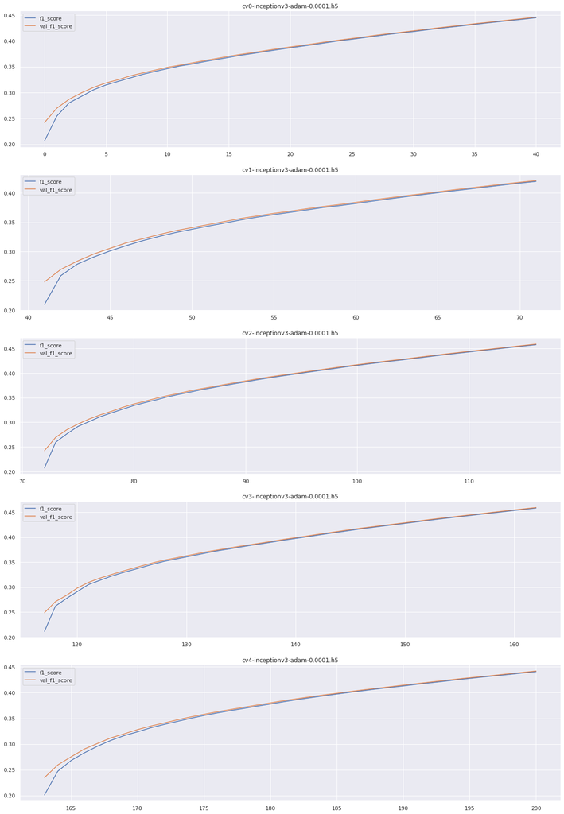

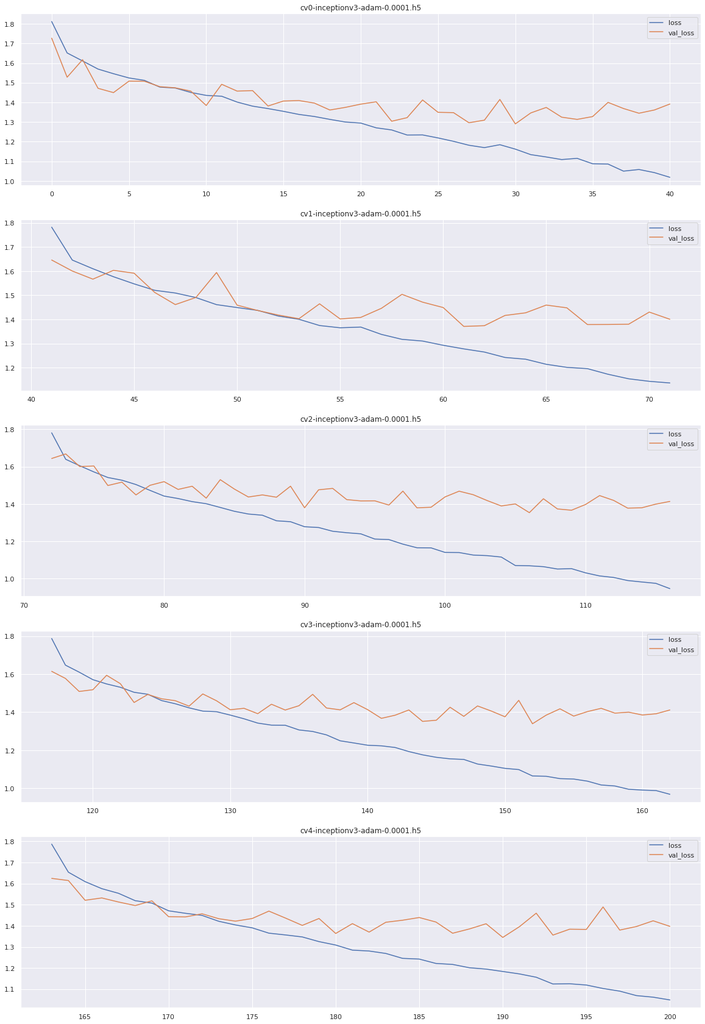

```python
plot_metrics = ['f1_score', 'loss']
to_remove = ['elapsed']

# Load results if saved
if os.path.isfile(CV_METRICS_RESULTS):
    df_best_model_results = pd.read_csv(CV_METRICS_RESULTS)

# Plot metrics for cv models
for metric in plot_metrics:
    selected = [f'{metric}', f'val_{metric}', 'file']
    grouped = df_best_model_results.drop(['elapsed'], axis=1)[selected].groupby(['file'])
    fig, axs = plt.subplots(nrows=len(grouped.groups.keys()), ncols=1)
    for key, ax in zip(grouped.groups.keys(), axs):
        _, title = key.split('/')
        grouped.get_group(key).plot(title=title, ax=ax, figsize=(20, 30))

# Plot best metrics tables for every cv model
for metric in plot_metrics:
    selected = selected = [f'{metric}', f'val_{metric}', 'file']
    display(df_best_model_results[selected].groupby(['file']).max())

display(df_best_model_results[['file', 'elapsed']].groupby(['file']).mean())
```

Vemos que el mejor modelo con los parámetros que hemos establecido es **cv3-inceptionv3-adam-0.0001.h5** el cual tiene **0.458246/0.459329** de `f1_score` en entrenamiento / validación respectivamente. Es el que más tiempo de entrenamiento ha empleado pero también porque es el modelo que más épocas ha utilizado en su entrenamiento. También podemos observar que simplemente aplicando esta técnica, con los mismos datos, hemos conseguido una mejora de **0.038695** en el modelo final.

### Ejercicio 4

- Presentar para el modelo que haya dado mejores resultados de la función de evaluación (F1-macro-average) las siguientes medidas de rendimiento adicionales: matriz de confusión, F1-score, Accuracy, Precision y Recall (todas ellas con media ponderada)
- Calcula las predicciones del conjunto de test proporcionado y guarda en un CSV con dos campos: nombre del archivo de la imagen analizada y clase predicha. El archivo debe tener la forma siguiente:

```
        image, label
        fichero1.jpg, C0
        fichero2.jpg, C5
        fichero3.jpg, C2
```

**Métricas**

Una vez obtenido el mejor modelo posible vamos a visualizar las métricas que se han pedido. En concreto su matriz de confusión y sus métricas *f1-score*, *accuracy*, *precission* y *recall*.

```python
nn = 'inceptionv3'
weights_path = os.path.join('tmp', 'cv3-inceptionv3-adam-0.0001.h5')
network, size, prepro = MODELS.get(nn)

print(f'Loading model from {weights_path}')
# Instantiate NN
clear_session()
best_model = generate_network(network_name=nn,
                              network_constructor=network,
                              input_size=size,
                              preprocess_function=prepro)
# Load best model
best_model.load_weights(weights_path)
print(best_model.summary())
```

```
Loading model from tmp/cv3-inceptionv3-adam-0.0001.h5
WARNING:tensorflow:Please add `keras.layers.InputLayer` instead of `keras.Input` to Sequential model. `keras.Input` is intended to be used by Functional model.
Model: "sequential"
_________________________________________________________________
Layer (type)                 Output Shape              Param #
=================================================================
module_wrapper (ModuleWrappe (None, 224, 224, 3)       0
_________________________________________________________________
inceptionv3-preprocessing (L (None, 224, 224, 3)       0
_________________________________________________________________
module_wrapper_1 (ModuleWrap (None, 5, 5, 2048)        21802784
_________________________________________________________________
inceptionv3-flatten (Flatten (None, 51200)             0
_________________________________________________________________
inceptionv3-dense-1024 (Dens (None, 1024)              52429824
_________________________________________________________________
inceptionv3-dropout (Dropout (None, 1024)              0
_________________________________________________________________
inceptionv3-output (Dense)   (None, 6)                 6150
=================================================================
Total params: 74,238,758
Trainable params: 52,435,974
Non-trainable params: 21,802,784
_________________________________________________________________
None
```

```python
# Load data
df_nn_data = df_norm[df_norm.model == nn]
_, val_data = next(gen_cv_folds(df_nn_data))

# Predict and plot results
predictions = best_model.predict(val_data)
val_pred = np.argmax(predictions, axis=-1)
val_true = val_data.classes

print(classification_report(y_true=val_true,
                            y_pred=val_pred,
                            target_names=val_data.class_indices.keys()))
```

```
Found 7800 validated image filenames belonging to 6 classes.
Found 1950 validated image filenames belonging to 6 classes.
              precision    recall  f1-score   support

          C0       0.40      0.32      0.36       800
          C1       0.09      0.10      0.10       200
          C2       0.15      0.23      0.18       240
          C3       0.14      0.10      0.12       220
          C4       0.12      0.14      0.13       260
          C5       0.10      0.10      0.10       230

    accuracy                           0.21      1950
   macro avg       0.17      0.17      0.16      1950
weighted avg       0.23      0.21      0.22      1950
```

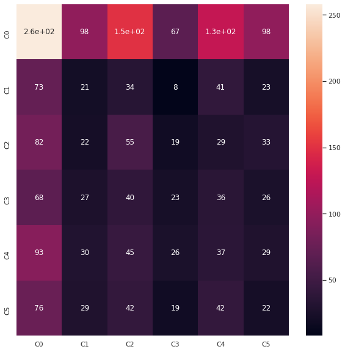

```python
cm = confusion_matrix(y_true=val_true, y_pred=val_pred)
labels = val_data.class_indices.keys()

fig, ax = plt.subplots(figsize=(10, 10))
f = sns.heatmap(cm, annot=True, xticklabels=labels, yticklabels=labels, ax=ax)
```

En apartados anteriores vimos que el conjunto de datos para la clase positiva **C0** tenía más datos que las demás. Por ello añadimos pesos de entrenamiento a cada clase con el fin de equilibrar las clasificaciones. Según vemos en los resultados de las métricas la clase que mejor detecta es la que más datos tiene. Parece que añadir pesos no ha tenido o como mínimo no ha hecho lo que pensábamos en un primer momento. Esto hará que el modelo tienda a clasificar la imagen como CO prácticamente por defecto.

**Predicciones**

```python
PREDS_FILE = 'test.csv'
BASE_TEST_PATH = os.path.join('data', 'norm', nn, 'test')
TOTAL_CLASSES = list(val_data.class_indices.keys())

# Input size for model
w, h, _ = size

preds_results = {
    'image': [],
    'label': []
}

# Predict class for a model
# Load and format image and then try to predict
# the class
def predict_image(image_name, model):
    # Load image
    image_path = os.path.join(BASE_TEST_PATH, image_name)
    img = image.load_img(image_path, target_size = (w, h))

    # Format to be compliant with model input
    img = image.img_to_array(img)
    img = np.expand_dims(img, axis=0)

    # Predict class
    pred = np.argmax(model.predict(img), axis=-1)[0]
    return TOTAL_CLASSES[0]

print(f'Predictions for {BASE_TEST_PATH}...')
# Iterate over test folder and get predictions for every file
for img_name in os.listdir(BASE_TEST_PATH):
    pred_class = predict_image(img_name, best_model)
    preds_results.get('image').append(img_name)
    preds_results.get('label').append(pred_class)
    df_preds = pd.DataFrame(preds_results)
    df_preds.to_csv(PREDS_FILE, index=False, header=True)

print('Done')
```

```
Predictions for data/norm/inceptionv3/test...
Done
```

**Conclusiones**

Hemos realizado un estudio con diferentes arquitecturas de red, estimadores y tasas de aprendizaje. También hemos realizado un proceso de *cross validation* con los datos de entrada para elegir la mejor combinación. Se nos ha presentado un reto en la realización de este trabajo y es la disponibilidad de un equipo más potente. Se optó por realizar una medición de los pesos de las clases y entrenar el modelo con estos, lo que no ha funcionado bien ya que el resultado final está sesgado para la clase positiva.

Con un proceso completo de *data augmentation* se podrían haber rectificado los pesos de las clases y es posible que el modelo final no tuviera este sesgo. Se podría o bien aumentar arfificialmente los datos de las clases menos representadas o dismunuir la cantidad de datos de entrenamiento para la clase más representada.